# Pendeln in Deutschland

Zeit für die Bahn? – Eine datenbasierte Analyse

# Motivation

Jeden Morgen das gleiche Bild: Verstopfte Autobahnen, genervte Pendler, verlorene Zeit. **20,5 Millionen Menschen** pendeln in Deutschland täglich zur Arbeit – die meisten davon mit dem Auto. Laut [INRIX Traffic Scorecard 2024](https://inrix.com/scorecard/) verlieren Pendler in deutschen Großstädten zwischen 40 und 60 Stunden pro Jahr allein im Stau. Das entspricht fast einer kompletten Arbeitswoche, die im Nichts verpufft.

Die Idee liegt auf der Hand: **Wer Bahn fährt, steht nicht im Stau.** Aber wie schlägt sich die Bahn im Vergleich zum Auto? Ist sie wirklich schneller? Und wie zuverlässig ist sie eigentlich?

In diesem Projekt analysieren Sie **Echtzeitdaten der Deutschen Bahn**, **Pendlerstatistiken der Bundesagentur für Arbeit**, **Staudaten von INRIX** und die **Entgeltstatistik der Bundesagentur für Arbeit**. Sie werden herausfinden, dass die Antwort auf die Frage “Sollten mehr Menschen Bahn fahren?” komplexer ist, als man zunächst vermuten würde und dass sie wichtige Implikationen für die Verkehrspolitik hat.

Ihre zentrale Forschungsfrage lautet:

> **“Sollten mehr Menschen Bahn fahren – und was müsste sich dafür ändern?”**

# Datengrundlage

In diesem Projekt arbeiten Sie mit mehreren Datensätzen. Ein wichtiger Teil des Projekts ist das **eigenständige Beschaffen von Primärdaten** aus offiziellen Quellen.

## Daten einlesen und verstehen

Bevor Sie mit der Analyse beginnen können, müssen Sie verschiedenste Datensätze einlesen und deren Struktur verstehen. Die Deutsche Bahn stellt über unterschiedliche Schnittstellen Echtzeitdaten für ihre Züge als open-source Daten zur Verfügung, welche per API-Calls geladen werden können. Jedoch gibt es von der Deutschen Bahn keine offizielle Seite, welche historische Daten zu Zugverspätungen, Ausfällen etc. für Fern- und Nahverkehrszüge sammelt. Da wir uns jedoch mit historischen Daten beschäftigen möchten, greifen wir auf Daten zurück, die von [Piet Brömmel](https://github.com/piebro/deutsche-bahn-data) gesammelt wurden und bei Huggingface im **Parquet-Format** zur Verfügung gestellt wurden. Das **Parquet-Format** ist ein effizientes Datenformat und wird oft für große Datenmengen genutzt; in R können Sie diese Daten mit dem `arrow`-Paket einlesen.

1. **Wie pünktlich ist die Bahn wirklich?** Um diese Frage zu beantworten, brauchen Sie echte Verspätungsdaten – nicht nur Pressemitteilungen. Die Bahndaten bilden das **Herzstück unserer Analyse**: Mit ihnen können Sie berechnen, wie viel Zeit Bahnfahrer durch Verspätungen verlieren und später mit den Stauzeiten der Autofahrer vergleichen.

Die Deutsche Bahn stellt Echtzeitdaten als Open Data zur Verfügung. Das Projekt piebro/deutsche-bahn-data auf Huggingface sammelt diese Daten im Parquet-Format.

Laden Sie die Datei für **November 2025** direkt von Huggingface herunter und lesen Sie diesen Datensatz als `bahn` in R ein.

Zeigen Sie die ersten 10 Zeilen des Datensatzes in einer Tabelle und beantworten Sie anschließend folgende Fragen:

- Wie viele Beobachtungen enthält der Datensatz? Welche Variablen sind vorhanden?
- Was stellt eine einzelne Beobachtung dar?

*Hinweis 1:* Sie können auf Huggingface die gesuchte Datei [hier](https://huggingface.co/datasets/piebro/deutsche-bahn-data/resolve/main/monthly_processed_data/data-2025-11.parquet) finden und direkt die URL zu der Datei in R mitgeben

*Hinweis 2:* Sie können die Parquet Datei entweder lokal speichern, oder immer direkt per URL einlesen. Falls Sie die Datei lokal speichern, so wird diese nicht auf GitHub Committet, da wir dies in der .gitignore entsprechend eingestellt haben. In diesem Fall sollten alle Teammitglieder die Datei lokal zur Verfügung haben.

*Hinweis 3:* Achten Sie bei allen Tabellen auf einer saubere Darstellung

Erste 10 Beobachtungen aus dem DB-Datensatz November 2025 (relevante Spalten)

| Bahnhof | Zug | Zielbahnhof | Verspätung [Min] | Ausgefallen | Ankunft geplant | Ankunft tatsächlich |
| --- | --- | --- | --- | --- | --- | --- |
| Stuttgart Hbf | S 2 | Filderstadt | 5 | FALSE | 2025-11-01 00:55:00 | 2025-11-01 00:57:00 |
| Halle (Saale) Hbf | S 5 | Leipzig Hbf (tief) | 1 | FALSE | NA | NA |
| Karlsruhe Hbf | RE 1 | Karlsruhe Hbf | 95 | FALSE | 2025-10-31 23:25:00 | 2025-11-01 01:00:00 |
| Regensburg Hbf | ALX RE25 | München Hbf | 11 | FALSE | 2025-11-01 00:35:00 | 2025-11-01 00:52:00 |
| Mannheim Hbf | ICE 775 | Karlsruhe Hbf | 1 | FALSE | 2025-11-01 00:56:00 | 2025-11-01 00:58:00 |
| Flughafen BER | S 9 | Flughafen BER | 1 | FALSE | 2025-11-01 00:59:00 | 2025-11-01 01:00:00 |
| Halle (Saale) Hbf | S 8 | Halle (Saale) Hbf | 15 | FALSE | 2025-11-01 00:45:00 | 2025-11-01 01:00:00 |
| München Hbf | RB 40 | München Hbf | 0 | FALSE | 2025-11-01 01:00:00 | 2025-11-01 01:00:00 |
| Köln Hbf | IC 1952 | Köln Hbf | 40 | FALSE | 2025-11-01 00:20:00 | 2025-11-01 01:00:00 |
| Freiburg (Breisgau) Hbf | S 1 | Freiburg (Breisgau) Hbf | 0 | FALSE | 2025-11-01 01:00:00 | 2025-11-01 01:00:00 |

*Wie viele Beobachtungen enthält der Datensatz? Welche Variablen sind vorhanden?*

Der Datensatz für November 2025 umfasst 13.943.561 Beobachtungen und enthält 16 Variablen. Er stellt eine umfassende Grundlage zur Analyse der Pünktlichkeit des deutschen Bahnverkehrs dar.

Erfasst werden der Name des Bahnhofs (station_name) sowie eine alternative, aus den Rohdaten stammende Stationsbezeichnung (xml_station_name) und die eindeutige Stationskennung (eva). Informationen zum Zug selbst liefern der Zugname (train_name), der Zugtyp (train_type) sowie die Endstation des Zuges (final_destination_station).

Zur zeitlichen Einordnung enthält der Datensatz den Zeitstempel der Beobachtung (time) sowie die planmäßigen Ankunfts- und Abfahrtszeiten (arrival_planned_time, departure_planned_time) und die jeweiligen Änderungen gegenüber dem Fahrplan (arrival_change_time, departure_change_time). Die daraus resultierende Verspätung in Minuten wird in der Variable delay_in_min festgehalten.

Zusätzlich wird erfasst, ob ein Zug ausgefallen ist (is_canceled). Zur eindeutigen Identifikation und Einordnung der Fahrt dienen die Zuglinien- bzw. Fahrt-ID (train_line_ride_id), die Stationsnummer innerhalb der Fahrt (train_line_station_num) sowie eine eindeutige Beobachtungs-ID (id).

*Was stellt eine einzelne Beobachtung dar?*

Eine einzelne Beobachtung repräsentiert einen konkreten Zughalt an einem bestimmten Bahnhof zu einem bestimmten Zeitpunkt. Da ein Zug während seiner Fahrt mehrere Bahnhöfe anfährt, entstehen pro Zug mehrere Beobachtungen. Diese feingranulare Struktur ermöglicht detaillierte Analysen von Verspätungen nach Zug, Strecke, Bahnhof und Zeitpunkt und bildet die Grundlage für den späteren Vergleich mit Stauzeiten im Straßenverkehr.

2. **Wohin pendeln die Menschen?** Die Bahndaten zeigen ihnen die Pünktlichkeit der Züge – aber um zu verstehen, wo gute Bahnverbindungen besonders wichtig sind, müssen Sie wissen, **wohin die Menschen pendeln**. Die Pendlerstatistik der Bundesagentur für Arbeit zeigt genau das: Welche Städte sind die größten Arbeitgeber-Magneten?

Laden Sie den Datensatz `pendler_kreise_aufbereitet.csv` aus dem Ordner `daten` in R ein als Datensatz `pendler`.

Erstellen Sie eine Tabelle der **Top 10 Städte** nach Einpendlern mit den Spalten: Stadt (kreis_name), Einpendler, Auspendler, Pendlersaldo.

Interpretieren Sie kurz: Welche Städte sind die größten “Pendlermagneten” Deutschlands und warum?

Top 10 Städte nach Anzahl der Einpendler

| Stadt | Einpendler | Auspendler | Pendlersaldo |
| --- | --- | --- | --- |
| München, Landeshauptstadt | 455.645 | 202.756 | 252.889 |
| Frankfurt am Main, Stadt | 405.856 | 111.245 | 294.611 |
| Hamburg, Freie und Hansestadt | 392.951 | 147.328 | 245.623 |
| Berlin, Stadt | 392.324 | 219.898 | 172.426 |
| Köln, Stadt | 306.905 | 138.422 | 168.483 |
| Düsseldorf, Stadt | 284.696 | 97.326 | 187.370 |
| Stuttgart, Landeshauptstadt | 274.442 | 100.095 | 174.347 |
| Nürnberg, Stadt | 165.496 | 78.557 | 86.939 |
| Essen, Stadt | 141.296 | 90.906 | 50.390 |
| Region Hannover | 137.924 | 69.974 | 67.950 |

**Interpretation**

*Welche Städte sind die größten “Pendlermagneten” Deutschlands und warum?*

Die größten „Pendlermagneten“ Deutschlands sind vor allem München, Frankfurt am Main und Hamburg. Diese Städte weisen die höchsten Einpendlerzahlen auf und erzielen zugleich einen deutlich positiven Pendlersaldo, was auf einen starken Nettozustrom von Arbeitskräften hinweist. München nimmt dabei mit rund 456.000 Einpendlern eine Spitzenposition ein, gefolgt von Frankfurt und Hamburg.

Die hohe Anziehungskraft dieser Städte erklärt sich vor allem durch ihre ökonomische Bedeutung und die Konzentration hochwertiger Arbeitsplätze. München ist ein zentraler Standort für Industrie, Technologie und wissensintensive Dienstleistungen, Frankfurt fungiert als führendes Finanz- und Dienstleistungszentrum Deutschlands, während Hamburg insbesondere durch Handel, Logistik und Medien geprägt ist.

Auch Berlin, Köln, Düsseldorf und Stuttgart zählen zu den wichtigsten Pendlerzielen, weisen jedoch einen etwas geringeren Pendlersaldo auf. Dies deutet auf ein ausgewogeneres Verhältnis zwischen Ein- und Auspendlern hin, etwa aufgrund größerer Wohnbevölkerung oder stärkerer suburbaner Verflechtungen.

Städte wie Nürnberg, Essen oder die Region Hannover fungieren vor allem als regionale Arbeitsmarktzentren. Sie ziehen zwar ebenfalls viele Pendler an, erreichen jedoch nicht die überregionale Magnetwirkung der größten Metropolen.

3. **Was kostet das Auto?** Sie haben jetzt Bahndaten und wissen, wohin die Menschen pendeln. Aber um fair vergleichen zu können, brauchen Sie auch die **Alternative**: Wie viel Zeit verlieren Autofahrer im Stau? Diese Daten liefert INRIX – ein Unternehmen, das weltweit Verkehrsdaten sammelt. Später werden Sie diese Staukosten mit den Bahnverspätungen vergleichen.

Besuchen Sie die [INRIX Global Traffic Scorecard](https://inrix.com/scorecard/) und suchen Sie die Stauzeiten für die Top 10 Städte aus Aufgabe 2 und zusätzlich die Stauzeiten für Ulm. INRIX misst, wie viele Stunden Autofahrer jährlich im Stau verlieren.

- Erstellen Sie eine eigene CSV-Datei `inrix_staedte_2024.csv` mit folgenden Spalten für die geforderten Städte:
  - `stadt`: Name der Stadt
  - `stau_stunden_jahr`: Jährliche Staustunden pro Fahrer
  - `kosten_eur`: Jährliche Kosten pro Fahrer (findet sich in der tiefergehenden Übersicht)
- Berechnen Sie für jede Stadt, wie viele **Arbeitstage pro Jahr** im Stau verloren gehen. Annahme: Ein Arbeitstag = 8 Stunden.

Erstellen Sie anschließend eine schöne Tabelle mit: Stadt, Staustunden/Jahr, verlorene Arbeitstage und beschreiben diese. In welcher Stadt ist die Stausituation am schlimmsten? Wie viele Arbeitstage verliert ein typischer Pendler dort pro Jahr?

*Hinweis:* Auf der INRIX-Website können Sie nach bei “Jump to City Rankings” -> “Search the List” -> “Germany” oder der konkreten Stadt filtern.

Jährliche Staubelastung in deutschen Städten (INRIX 2025)

| Stadt | Staustunden/Jahr | Verlorene Arbeitstage | Jährliche Kosten pro Fahrer [€] |
| --- | --- | --- | --- |
| Köln | 67 | 8.4 | 919 |
| Düsseldorf | 63 | 7.9 | 864 |
| Berlin | 60 | 7.5 | 823 |
| Stuttgart | 60 | 7.5 | 823 |
| München | 57 | 7.1 | 781 |
| Frankfurt am Main | 55 | 6.9 | 754 |
| Region Hannover | 54 | 6.8 | 740 |
| Hamburg | 46 | 5.8 | 631 |
| Essen | 46 | 5.8 | 631 |
| Nürnberg | 38 | 4.8 | 521 |
| Ulm | 30 | 3.8 | 411 |

**Beschreibung**

Die INRIX-Daten liefern eine Übersicht darüber, wie stark Autofahrer in deutschen Städten jährlich durch Staus belastet werden. Die Tabelle zeigt die jährlichen Staustunden pro Fahrer, die sich in verlorene Arbeitstage umrechnen lassen (1 Arbeitstag = 8 Stunden), sowie die damit verbundenen jährlichen Kosten.

Die größte Belastung besteht in den wirtschaftlich stark frequentierten Städten Köln, Düsseldorf, Berlin, Stuttgart, München und Frankfurt am Main, wo Pendler im Durchschnitt zwischen rund 55 und 67 Staustunden pro Jahr verlieren, was etwa 6,9 bis 8,4 verlorenen Arbeitstagen entspricht. Kleinere Städte wie Nürnberg, Ulm oder Essen sind deutlich weniger betroffen, mit weniger als sechs Arbeitstagen pro Jahr, was die Unterschiede in Stadtgröße, Pendleraufkommen und Verkehrsinfrastruktur verdeutlicht.

*In welcher Stadt ist die Stausituation am schlimmsten und wie viele Arbeitstage verliert ein typischer Pendler dort pro Jahr?*

Die Analyse zeigt, dass Köln die höchste Staubelastung aufweist: Ein typischer Autofahrer verliert hier jährlich 67 Stunden, das entspricht 8,4 Arbeitstagen, und verursacht Kosten von etwa 919 €.

4. Für die weiteren Analysen stellen wir Ihnen **fünf zusätzliche Datensätze** bereit. Diese laden Sie jetzt, damit sie in allen folgenden Aufgaben direkt verfügbar sind.

Laden Sie die folgenden Datensätze aus dem Ordner `daten` und speichern Sie diese unter den angegebenen Variablennamen:

| Datei | Variablenname | Verwendet in |
| --- | --- | --- |
| `bahnhof_ags_mapping.csv` | `bahnhof_mapping` | Aufgabe 9-10 |
| `fahrtzeit_osrm_vergleich.csv` | `fahrtzeit` | Aufgabe 12 |
| `ulm_pendlerrouten.csv` | `ulm_routen` | Aufgabe 13 |
| `ba_entgeltstatistik_2024.csv` | `entgelt` | für `staedte_basis` |
| `co2_analyse.csv` | `co2_analyse` | Aufgabe 19 (Bonus) |

Verschaffen Sie sich einen ersten Überblick über die Struktur der Daten (z.B. mit `glimpse()`, dies sollte später in ihrem HTML Dokument nicht sichtbar sein!).

**Erstellen Sie außerdem einen Master-Datensatz** `staedte_basis` für die Top-11-Städte (Top 10 Pendlerstädte + Ulm), der die Daten aus `pendler`, `entgelt` und `inrix` kombiniert. Dieser Datensatz vereinfacht die späteren Analysen (ab Aufgabe 14), da alle relevanten Kennzahlen bereits zusammengeführt sind.

Der Master-Datensatz sollte folgende Spalten enthalten:

- `ags`: Amtlicher Gemeindeschlüssel
- `stadt`: Stadtname (Kurzform, z.B. “München”)
- `einpendler`: Anzahl Einpendler
- `median_monat_eur`: Medianlohn pro Monat
- `median_stunde_eur`: Medianlohn pro Stunde (Monatslohn / 160)
- `stau_stunden_jahr`: Stauzeit pro Jahr (aus INRIX)

*Hinweis 1:* Die Datensätze verwenden unterschiedliche Namensformate: `pendler` hat offizielle Namen (“München, Landeshauptstadt”), während `entgelt` und `inrix` Kurznamen (“München”) verwenden. Nutzen Sie den **AGS** als zuverlässigen Schlüssel für die Verknüpfung mit `pendler`. Tipp: `entgelt` enthält sowohl AGS als auch Kurznamen und eignet sich daher gut als Ausgangspunkt.

*Hinweis 2:* Eine ausführliche Beschreibung der Datensätze finden Sie im **Anhang A**.

# Die Pünktlichkeit der Deutschen Bahn

Nachdem Sie nun einen Überblick über die Daten haben, welche wir in diesem Projekt verwenden möchten, tauchen Sie tiefer in die Bahndaten ein. Die zentrale Frage ist: **Wie zuverlässig ist die Deutsche Bahn wirklich?**

Die Bahn unterscheidet verschiedene Zugtypen, vom ICE über den RE bis zur S-Bahn. Jeder Zugtyp hat unterschiedliche Eigenschaften: Der ICE fährt lange Strecken mit wenigen Halten, die S-Bahn kurze Strecken mit vielen Halten. Aber welcher Zugtyp ist am pünktlichsten?

5. **Welche Züge sind (un)pünktlich?** Nicht alle Züge sind gleich: Der ICE fährt lange Strecken mit wenigen Halten, die S-Bahn kurze Strecken mit vielen Halten. Um später sinnvolle Empfehlungen geben zu können, müssen Sie verstehen, **welche Zugtypen besonders problematisch sind**. Dafür klassifizieren Sie die Züge anhand ihrer Namen. Nutzen Sie für diese Analyse den Datensatz `bahn`.

Die Variable `train_name` enthält den Zugnamen (z.B. “ICE 123”, “S 5”, “RE 8”).

- Erstellen Sie eine neue Variable `zugtyp` mit folgenden Kategorien:

| Zugtyp | Regel | Beispiel |
| --- | --- | --- |
| ICE | beginnt mit “ICE” | ICE 123 |
| IC/EC | beginnt mit “IC” oder “EC” | IC 2012, EC 6 |
| IRE/RE | beginnt mit “RE” oder “IRE” | RE 5, IRE 200 |
| RB | beginnt mit “RB” | RB 26 |
| S-Bahn | beginnt mit “S” (mit Leerzeichen!) | S 5 |
| Sonstige | alle anderen | U 6, STB 123 |

Erstellen Sie auf dieser Basis eine Tabelle, welche pro Zugtyp folgende Kennzahlen anschaulich darstellt:

- Anzahl der Fahrten
- Durchschnittliche Verspätung (in Minuten)
- Anteil pünktlicher Züge (≤6 Min Verspätung)
- Ausfallquote

Beschreiben und Interpretieren Sie die Tabelle.

Weiterhin sollten Sie ihre Ergebnisse verifizieren. Dafür können Sie auf die offizielle Pünktlichkeitswerte der Deutschen Bahn zurückgreifen (recherchieren Sie diese selbstständig).

Stimmen Ihre Ergebnisse mit den offiziellen Werten überein? Falls nicht: Welche methodischen Unterschiede könnten die Abweichung erklären?

*Hinweis:* Nutzen Sie `str_detect()` aus dem `stringr`-Paket. Achten Sie auf die Reihenfolge der Bedingungen!

Übersicht der Pünktlichkeit nach Zugtyp

| Zugtyp | Anzahl Fahrten | Durchschnittliche Verspätung [Min] | Anteil pünktlicher Züge (≤6 Min Verspätung) [%] | Ausfallquote [%] |
| --- | --- | --- | --- | --- |
| S-Bahn | 6.414.045 | 2,9 | 87,4 | 5,5 |
| Sonstige | 2.938.815 | 3,5 | 84,7 | 2,6 |
| RB | 2.675.028 | 3,5 | 85,2 | 3,2 |
| IRE/RE | 1.673.555 | 6,1 | 74,1 | 3,6 |
| ICE | 171.516 | 12,5 | 56,7 | 4,2 |
| IC/EC | 70.602 | 11,0 | 60,2 | 7,2 |

**Beschreibung**

Die Tabelle zeigt die Pünktlichkeitskennzahlen der Deutschen Bahn, aufgeschlüsselt nach Zugtyp. Sie enthält die Anzahl der Fahrten, die durchschnittliche Verspätung in Minuten, den Anteil pünktlicher Züge (≤6 Minuten Verspätung) und die Ausfallquote.

Nahverkehrszüge wie S-Bahn, RE und RB machen den Großteil der Fahrten aus und weisen im Vergleich zu Fernverkehrszügen relativ geringe Verspätungen auf. Besonders die S-Bahn sticht hervor: Mit über 6,4 Millionen Fahrten hat sie nicht nur die höchste Anzahl an Verbindungen, sondern auch die niedrigste durchschnittliche Verspätung von 2,9 Minuten. Der Anteil pünktlicher Züge liegt bei 87,4 %, die Ausfallquote bei 5,5 %.

Die Kategorie „Sonstige“ umfasst alle übrigen Züge, die nicht eindeutig einem Haupttyp zugeordnet sind. Sie zeigt ebenfalls vergleichsweise geringe Verspätungen, enthält jedoch eine breite Mischung von Verbindungen.

**Interpretation**

Die Unterschiede zwischen Nah- und Fernverkehr lassen sich durch die Betriebsbedingungen erklären. Fernverkehrszüge legen lange Strecken zurück, haben wenige Halte und kumulieren Verspätungen über die gesamte Strecke, wodurch die Pünktlichkeit sinkt. Nahverkehrszüge verkehren auf kürzeren Strecken mit häufigerem Halt und festen Taktungen, was die Stabilität erhöht.

**Vergleich mit offiziellen Werten**

*Stimmen die Ergebnisse mit den offiziellen Werten überein?*

Die Deutsche Bahn veröffentlicht regelmäßig offizielle Pünktlichkeitskennzahlen. Für November 2025 gibt die DB an, dass der DB Nahverkehr eine betriebliche Pünktlichkeit von rund 85,2 % [^1] erreicht, während der DB Fernverkehr lediglich etwa 54,5 % [^2] pünktliche Züge verzeichnet.

Diese offiziellen Werte stimmen in ihrer Größenordnung weitgehend mit den Ergebnissen der vorliegenden Analyse überein. In den eigenen Berechnungen liegt der Anteil pünktlicher Züge im Nahverkehr (S-Bahn, RB, RE/IRE) zwischen etwa 74 % und 87 %, während der Fernverkehr (ICE, IC/EC) deutlich schlechtere Werte von rund 57 % bis 60 % aufweist. Damit bestätigt der Datensatz grundsätzlich das bekannte Muster: Nahverkehrszüge sind signifikant pünktlicher als Fernverkehrszüge.

Abweichungen zeigen sich jedoch im Detail. Insbesondere liegt der berechnete Pünktlichkeitswert für den Fernverkehr leicht über dem offiziell gemeldeten Wert der DB, während einzelne Nahverkehrszugtypen teilweise unter oder über dem offiziellen Durchschnitt liegen.

*Welche methodischen Unterschiede könnten die Abweichung erklären?*

Die Abweichungen zwischen den Ergebnissen dieser Analyse und den offiziellen Pünktlichkeitswerten der Deutschen Bahn lassen sich durch mehrere methodische Unterschiede erklären. Obwohl beide Auswertungen auf der Definition der betrieblichen Pünktlichkeit basieren, unterscheiden sie sich in der Aggregation der haltbezogenen Verspätungen. In der vorliegenden Analyse wird jeder Verkehrshalt gleich gewichtet und anschließend nach Zugtypen zusammengefasst. Dadurch können Zugtypen mit vielen Halten pro Fahrt – insbesondere S-Bahnen – einen überproportionalen Einfluss auf die Ergebnisse erhalten.

Zudem kann eine Verspätung entlang einer einzelnen Fahrt mehrfach in die Statistik eingehen, wenn sie an mehreren aufeinanderfolgenden Halten auftritt. Dieser Effekt verstärkt insbesondere im Fernverkehr den Einfluss langanhaltender Verspätungen. Die offizielle Pünktlichkeitsstatistik der DB glättet solche Effekte teilweise durch eine andere Aggregationslogik und durch ergänzende fahrten- und reisendenbezogene Kennzahlen.

Weitere methodische Unterschiede ergeben sich aus dem Umgang mit fehlenden Zeitstempeln sowie der Behandlung von Zugausfällen. Während der Datensatz Beobachtungen mit unvollständigen Zeitangaben enthält und Ausfälle separat ausgewiesen werden, greift die DB auf vollständig validierte Betriebsdaten zurück und verwendet intern einheitliche Filter- und Berechnungsregeln. Schließlich können Unterschiede in der zeitlichen Abgrenzung des Betrachtungszeitraums, insbesondere bei Ankünften rund um Mitternacht, zu leichten Abweichungen in den aggregierten Kennzahlen führen.

Insgesamt erklären diese methodischen Unterschiede die geringfügigen Abweichungen, während die grundsätzliche Tendenz – Nahverkehrszüge sind deutlich pünktlicher als Fernverkehrszüge – erhalten bleibt.

6. In Aufgabe 5 haben Sie gesehen, dass Fernverkehrszüge (ICE, IC/EC) deutlich höhere Verspätungen und Ausfallquoten haben als Nahverkehrszüge (IRE, RE, RB, S-Bahn). Aber wie relevant ist das für den typischen Pendler? Das hängt davon ab, **wie viele Züge** jeweils unterwegs sind. Nutzen Sie für diese Analyse den Datensatz `bahn` (mit der in Aufgabe 5 erstellten Variable `zugtyp`).

Klassifizieren Sie die Züge in zwei Kategorien:

- **Fernverkehr**: ICE, IC/EC
- **Nahverkehr**: IRE, RE, RB, S-Bahn

Erstellen Sie ein **Liniendiagramm**, das die **durchschnittliche Anzahl der Fahrten pro Stunde** im Tagesverlauf zeigt:

- X-Achse: Uhrzeit (0-23 Uhr)
- Y-Achse: Durchschnittliche Anzahl Fahrten pro Stunde
- Zwei Linien: eine für Fernverkehr, eine für Nahverkehr (unterschiedliche Farben)

*Tipp:* Extrahieren Sie die Stunde aus der Variable `time` mit `hour()` aus dem `lubridate`-Paket. Berechnen Sie dann die durchschnittliche Anzahl Fahrten pro Stunde und Zugtyp.

Beschreiben und interpretieren Sie ihre Grafik. Beantworten Sie zusätzlich die folgenden Fragen:

- Zu welchen Uhrzeiten fahren die meisten Züge?
- Wie unterscheidet sich das Muster zwischen Fern- und Nahverkehr?
- Warum ist diese Information wichtig, wenn wir später die Verspätungen analysieren?

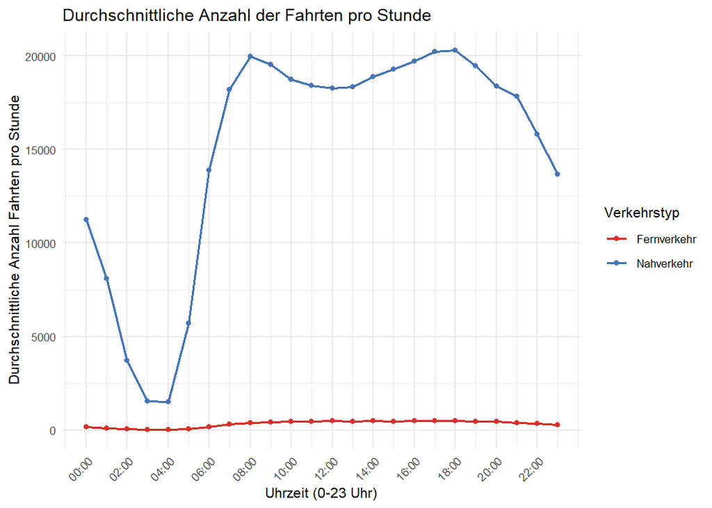

**Beschreibung**

Die Grafik zeigt die durchschnittliche Anzahl der Zugfahrten pro Stunde über den gesamten Tagesverlauf hinweg und unterscheidet dabei zwischen Fernverkehr (ICE, IC/EC) und Nahverkehr (z. B. S-Bahn, RB, RE). Auf der x-Achse ist die Uhrzeit von 0 bis 23 Uhr dargestellt, während die y-Achse die durchschnittliche Anzahl der Fahrten pro Stunde angibt.

Insgesamt übertrifft der Nahverkehr mengenmäßig deutlich den Fernverkehr. Während der Fernverkehr pro Stunde nur einige hundert Fahrten verzeichnet, erreicht der Nahverkehr in den Hauptverkehrszeiten bis zu zwanzigtausend Fahrten. In den Nachtstunden zwischen etwa 1:00 und 4:00 Uhr ist das Verkehrsaufkommen in beiden Bereichen deutlich reduziert. Ab den frühen Morgenstunden steigt die Anzahl der Fahrten an, mit Spitzen am Morgen (ca. 7:00–9:00 Uhr) und am späten Nachmittag/Abend (ca. 16:00–19:00 Uhr).

**Interpretation**

Die dargestellten Muster lassen sich durch die unterschiedliche Nutzung von Fern- und Nahverkehr erklären. Der Nahverkehr ist stark vom Berufs- und Pendlerverkehr geprägt, was sich in klaren Verkehrsspitzen am Morgen und am späten Nachmittag widerspiegelt. Viele Fahrgäste nutzen in diesen Zeiträumen S-Bahnen und Regionalzüge für den Weg zur Arbeit oder zur Schule sowie für die Rückfahrt am Abend. Der Fernverkehr weist hingegen ein deutlich gleichmäßigeres Tagesprofil auf. Zwar ist auch hier ein Anstieg der Fahrten im Laufe des Tages erkennbar, jedoch fallen die Schwankungen deutlich geringer aus. Dies deutet darauf hin, dass Fernverkehrsreisen weniger an feste Tageszeiten gebunden sind und eher über den gesamten Tag verteilt stattfinden.

*Zu welchen Uhrzeiten fahren die meisten Züge?*

Die meisten Fahrten finden während der Hauptverkehrszeiten statt: morgens etwa zwischen 7:00 und 9:00 Uhr und nachmittags/abends zwischen 16:00 und 19:00 Uhr.

*Wie unterscheidet sich das Muster zwischen Fern- und Nahverkehr?*

Der Unterschied zwischen Fern- und Nahverkehr zeigt sich vor allem in der tageszeitlichen Verteilung der Fahrten. Der Nahverkehr weist ein ausgeprägtes Doppelhoch in den Hauptverkehrszeiten sowie einen starken Rückgang in den Nachtstunden auf. Der Fernverkehr hingegen verläuft deutlich gleichmäßiger über den Tag hinweg und unterliegt geringeren tageszeitlichen Schwankungen.

*Warum ist diese Information wichtig, wenn wir später die Verspätungen analysieren?*

Die Kenntnis des zeitlichen Fahrtenaufkommens ist eine wichtige Voraussetzung für die Analyse von Verspätungen. In Phasen mit hoher Zugdichte ist die Schieneninfrastruktur stärker ausgelastet, wodurch sich die Wahrscheinlichkeit von Störungen und Folgeverspätungen erhöht. Verspätungen entstehen somit unter sehr unterschiedlichen Betriebsbedingungen, abhängig von Tageszeit und Verkehrsaufkommen. Darüber hinaus unterscheiden sich Fern- und Nahverkehr deutlich in ihrer zeitlichen Nutzung, weshalb Verspätungen nur dann sinnvoll verglichen werden können, wenn diese Unterschiede berücksichtigt werden.Für den typischen Pendler ist dabei vor allem die Pünktlichkeit des Nahverkehrs relevant, da dieser den überwiegenden Teil der Fahrten in den Hauptverkehrszeiten stellt.

Nachdem Sie in Aufgabe 6 herausgefunden haben, dass es deutlich mehr Nahverkehrszüge als Fernverkehrszüge gibt, und diese für Pendler wichtiger sind, sollten Sie sich die Verspätungen der Nahverkehrszüge über den Tag anschauen, da diese vermutlich nicht gleichmäßig über den Tag verteilt sind. Pendler erleben die Bahn vor allem in der **Hauptverkehrszeit**, d.h. morgens zwischen 7 und 9 Uhr und abends zwischen 16 und 19 Uhr. Aber ist die Bahn zu diesen Zeiten besonders unpünktlich?

7. Erstellen Sie zwei **Heatmaps**, die zeigen, wie sich die Verspätungen nach **Tageszeit** (Stunde) und **Wochentag** für die Nahverkehrszüge und die Fernverkehrszüge verteilen. Nutzen Sie für diese Analyse den Datensatz `bahn`.
- Extrahieren Sie aus der Variable `time` die Stunde und den Wochentag.
- Filtern Sie auf die **relevanten Tageszeiten** (5-23 Uhr), da nachts kaum Zugverkehr stattfindet.
- Aggregieren Sie die durchschnittliche Verspätung pro Stunde und Wochentag für Nah- und Fernverkehrszüge separat.
- Erstellen Sie eine Heatmap mit `ggplot2` und `geom_tile()`.

*Tipp zur Farbskala:* Da Fernverkehrszüge im Durchschnitt höhere Verspätungen haben als Nahverkehrszüge, können Sie **unterschiedliche Farbskalen** für die beiden Heatmaps verwenden (z.B. Blau-Töne für Nahverkehr, Rot-Töne für Fernverkehr). Dadurch werden die Muster innerhalb jeder Verkehrsart besser sichtbar.

Beschreiben und interpretieren Sie ihre Grafiken.

- Wann sind die Verspätungen am höchsten?
- Gibt es Unterschiede zwischen Werktagen und Wochenende?
- Gibt es Unterschiede zwischen Nah- und Fernverkehrszügen?
- Was bedeutet das für Pendler?

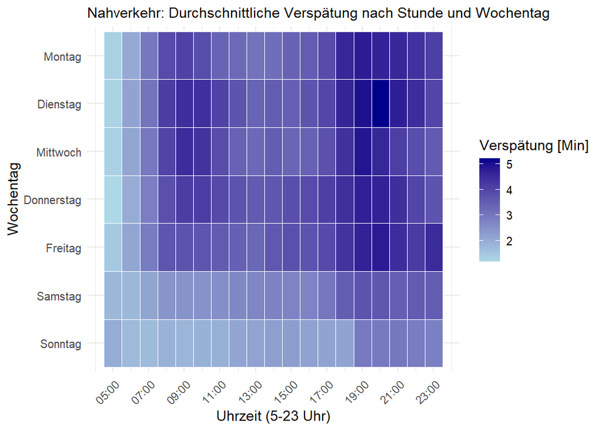

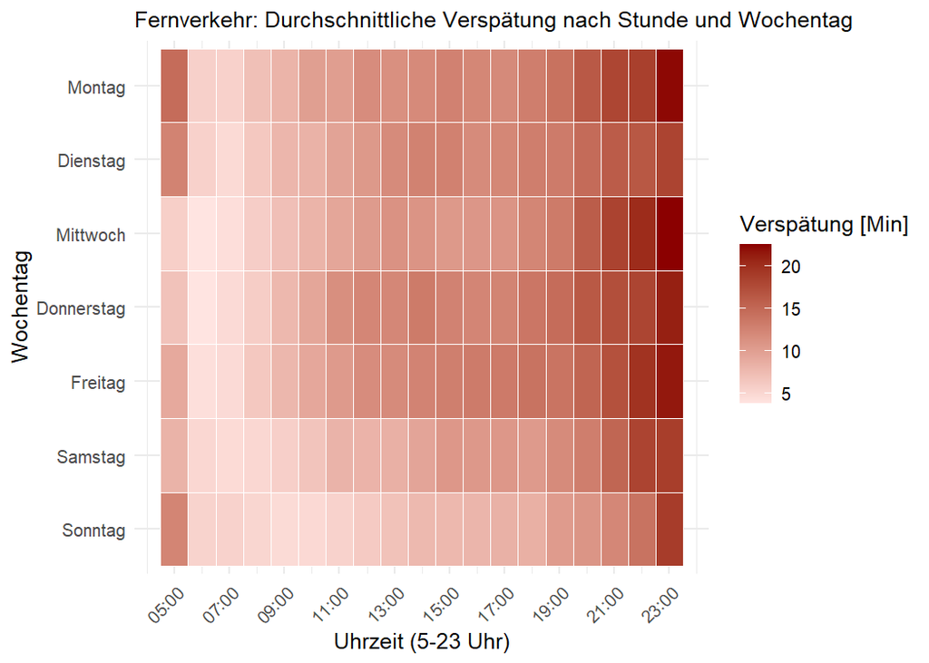

**Beschreibung**

Die beiden Heatmaps visualisieren die durchschnittlichen Verspätungen von Zügen in Abhängigkeit von der Stunde des Tages (5–23 Uhr) und dem Wochentag (Montag–Sonntag). Die x-Achse repräsentiert die Stunden, die y-Achse die Wochentage, während die Farbskala die Höhe der Verspätung in Minuten anzeigt. Dunklere Farben stehen für längere Verspätungen.

Im Fernverkehr sind die Verspätungen deutlich ausgeprägter und erreichen in Spitzenzeiten Werte von über 20 Minuten. Bereits in den frühen Morgenstunden um 5 Uhr treten signifikante Verspätungen auf. Die größten Verzögerungen zeigen sich vor allem in den Abendstunden ab etwa 20 Uhr. Auch hier lassen sich Unterschiede zwischen Werktagen und Wochenende erkennen: Am Wochenende fallen die Verspätungen insgesamt geringer aus, einzelne Spitzen bleiben jedoch bestehen.

**Interpretation**

Die Analyse der Heatmaps zeigt deutlich, dass die Verspätungen stark von der Tageszeit, dem Wochentag und der Art des Zugverkehrs abhängen.

*Wann sind die Verspätungen am höchsten?*

Im Nahverkehr treten die höchsten Verspätungen während der klassischen Pendlerzeiten am Morgen und am Abend auf. Dies ist auf die hohe Auslastung des Netzes zurückzuführen: Viele gleichzeitig fahrende Pendler führen zu Verzögerungen, die sich in den Heatmaps deutlich darstellen.

Im Fernverkehr treten die größten Verzögerungen in den Abendstunden ab etwa 20 Uhr auf. Diese Verzögerungen sind häufig kumulativ, da Fernverkehrszüge längere Strecken bedienen und einzelne Verspätungen auf nachfolgende Züge wirken. Außerdem zeigen die Daten, dass bereits in den frühen Morgenstunden um 5 Uhr viele Verspätungen bestehen. Dies deutet auf Übertragungen von Verspätungen aus der vorherigen Nacht oder auf logistische Komplexität der Fernverkehrsplanung hin.

*Gibt es Unterschiede zwischen Werktagen und Wochenende?*

An Werktagen sind die Verspätungen sowohl im Nah- als auch im Fernverkehr generell höher. Im Nahverkehr ist dies besonders ausgeprägt, da das Zugnetz durch Pendlerfahrten stark belastet wird. Fernverkehrszüge sind ebenfalls anfälliger für Verzögerungen, da kleine Störungen über lange Strecken verstärkt werden.

Am Wochenende sind die Verspätungen insgesamt geringer, da die Auslastung des Netzes reduziert ist. Einzelne Spitzenwerte, insbesondere bei stark nachgefragten Verbindungen am Abend, bleiben jedoch bestehen.

*Gibt es Unterschiede zwischen Nah- und Fernverkehrszügen?*

Nahverkehrszüge zeigen überwiegend geringe Verspätungen (<5 Minuten). Ihre kurzen, taktgebundenen Strecken ermöglichen eine schnelle Kompensation kleiner Verzögerungen.

Fernverkehrszüge weisen dagegen deutlich höhere Verzögerungen auf, oft über 10 Minuten, mit Spitzenwerten über 20 Minuten. Die längeren Strecken, geringere Anzahl an Halten und die Vernetzung mit anderen Zügen führen dazu, dass sich Verspätungen stärker akkumulieren. Somit ist die Pünktlichkeit im Fernverkehr im Mittel deutlich schlechter als im Nahverkehr.

*Was bedeutet das für Pendler?*

Für Pendler im Nahverkehr lassen sich daraus folgende Schlüsse ziehen: Die Verbindungen sind grundsätzlich zuverlässig, jedoch sollten während der Stoßzeiten morgens und abends geringe Verzögerungen eingeplant werden.

Für Fernverkehrspendler ergeben sich höhere Risiken für längere Verspätungen, insbesondere bei Abendfahrten und frühen Morgenfahrten um 5 Uhr. Es empfiehlt sich, Pufferzeiten einzuplanen oder alternative Verbindungen in Betracht zu ziehen. Insgesamt verdeutlichen die Heatmaps, dass Verspätungen kein zufälliges Phänomen sind, sondern systematisch von Tageszeit, Wochentag und Verkehrsart abhängen, was für Pendler eine gezielte zeitliche Planung besonders relevant macht.

## Von der Zeit zum Ort: Wo entstehen die Verspätungen?

In Aufgabe 7 haben Sie analysiert, **wann** die Verspätungen auftreten, nämlich vor allem zu den Hauptverkehrszeiten. Aber die nächste wichtige Frage ist: **Wo** entstehen diese Verspätungen?

Aggregierte Statistiken wie Durchschnittswerte über ganz Deutschland verbergen oft große regionale Unterschiede. Vielleicht gibt es einzelne “Problembahnhöfe”, die den Durchschnitt nach oben ziehen? Oder sind die Verspätungen gleichmäßig über das Netz verteilt? Diese Frage ist wichtig, weil sie unterschiedliche Lösungsansätze impliziert: Bei wenigen Problembahnhöfen könnte die Bahn gezielt investieren, bei flächendeckenden Problemen bräuchten Sie systemische Lösungen.

8. Identifizieren Sie die **10 unpünktlichsten Bahnhöfe** in Deutschland (mit mindestens 1.000 Halten im Monat). Nutzen Sie für diese Analyse den Datensatz `bahn`.

Erstellen Sie ein Balkendiagramm, das die durchschnittliche Verspätung dieser Bahnhöfe zeigt. Beschriften Sie die Balken mit den Verspätungswerten.

Beschreiben und interpretieren Sie ihre Grafik.

- Sehen Sie ein geografisches Muster?
- Handelt es sich um große Knotenbahnhöfe oder eher um kleinere Stationen?

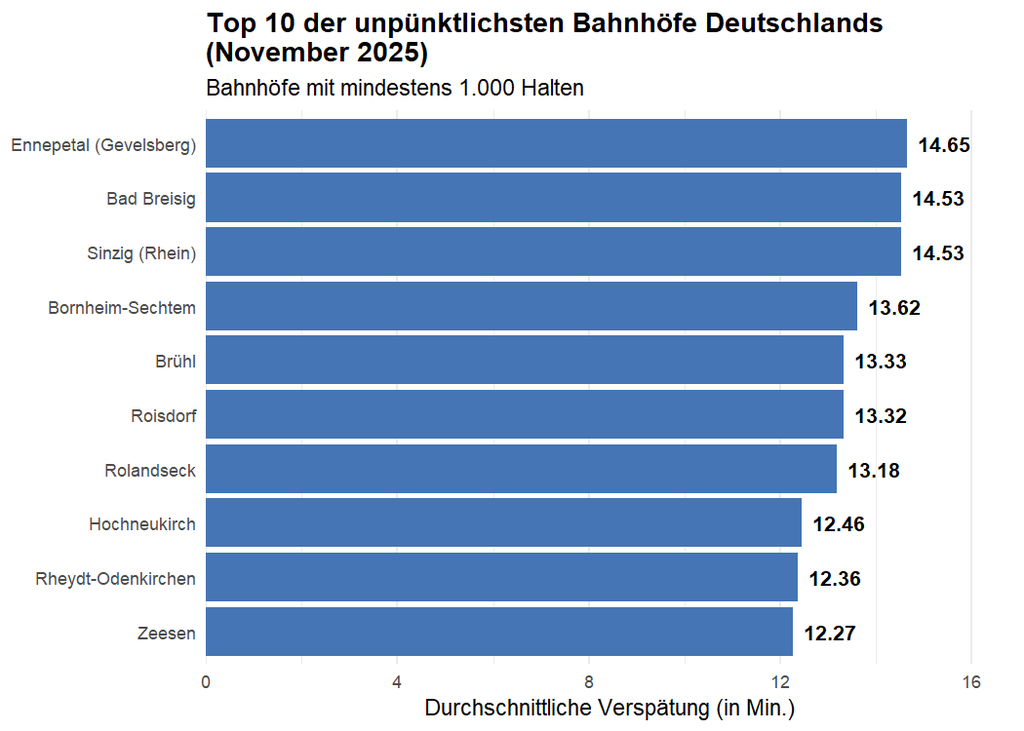

**Beschreibung**

Die Grafik zeigt die Top-10 der unpünktlichsten Bahnhöfe in Deutschland, sortiert nach der durchschnittlichen Verspätung im November 2025. Auf der y-Achse sind die jeweiligen Bahnhöfe angeordnet, während die x-Achse die durchschnittliche Verspätung in Minuten angibt. In der Grafik wurden nur Bahnhöfe berücksichtigt, die mindestens 1.000 Halte pro Monat aufweisen. Zu erkennen ist, dass die durchschnittliche Verspätung zwischen 12,27 und 14,65 Minuten liegt. Die Balken sind absteigend nach der Verspätung geordnet, sodass oben Ennepetal (Gevelsberg) mit der höchsten durchschnittlichen Verspätung zu sehen ist. Jeder Balken ist dabei mit der gerundeten durchschnittlichen Verspätung beschriftet, sodass die geringen Unterschiede leicht und genau erkennbar sind.

**Interpretation**

*Sehen Sie ein geografisches Muster?*

*Handelt es sich um große Knotenbahnhöfe oder eher um kleinere Stationen?*

Bei den in der Grafik aufgelisteten Bahnhöfen handelt es sich hauptsächlich um kleine bis mittelgroße Stationen. Große Bahnhöfe wie Frankfurt (Main) Hbf, München Hbf oder Berlin Hbf treten in der Grafik hingegen gar nicht auf. Obwohl es sich um kleinere Stationen handelt, treten hier die höchsten Verspätungen von durchschnittlich 12,27 bis 14,65 Minuten auf. Ursache dafür könnten beispielsweise ein eng getakteter Regionalverkehr oder auch viele Baustellen sein.

Zusammenfassend kann man sagen, dass Verspätungen vor allem kleinere bis mittelgroße Bahnhöfe in Westdeutschland betreffen. Dabei scheinen regionale Faktoren eine größere Rolle zu spielen, als die Größe des Bahnhofs.

# Wo treffen viele Pendler auf eine unpünktliche Bahn?

Bisher haben Sie Pendler- und Bahndaten getrennt betrachtet. Aber die spannende Frage ist: **Wo kommen beide Probleme zusammen?** Eine Stadt mit vielen Pendlern und einer unpünktlichen Bahn hat ein größeres Problem als eine Stadt mit wenigen Pendlern und einer unpünktlichen Bahn.

Um diese Frage zu beantworten, müssen Sie die Datensätze verknüpfen. Das Problem: Die Bahndaten sind auf Bahnhofsebene, die Pendlerdaten auf Kreisebene. Sie benötigen ein **Mapping**, das Bahnhöfe den entsprechenden Kreisen zuordnet.

9. In dieser Aufgabe verknüpfen Sie die Bahn- und Pendlerdaten, um Städte mit Handlungsbedarf zu identifizieren. Nutzen Sie für ihre Analysen die Datensätze: `bahn`, `pendler` und `bahnhof_mapping`.

Das Mapping ordnet Bahnhöfe ihrem Landkreis zu (via AGS = Amtlicher Gemeindeschlüssel). Ihr Ziel: Identifizieren Sie Städte, in denen **viele Pendler auf eine unpünktliche Bahn** treffen.

- Berechnen Sie für jeden Bahnhof die durchschnittliche Verspätung und die Anzahl der Halte.
- **Aggregation auf Kreisebene:** Berechnen Sie für jeden Kreis die **gewichtete durchschnittliche Verspätung**. Gewichten Sie nach der Anzahl der Halte (ein Bahnhof mit 10.000 Halten zählt mehr als einer mit 100).
- Verknüpfen Sie das Ergebnis mit den Pendlerdaten mittels `left_join()` über die Variable `ags`.
- **Problem-Score berechnen:** Kombinieren Sie beide Dimensionen mit z-Standardisierung:

$$\text{Problem-Score} =
z(\text{Einpendler}) + z(\text{Verspätung})$$

Die z-Standardisierung macht die Werte vergleichbar: $z(x) = \frac{x - \bar{x}}{s_x}$, wobei $\bar{x}$ der Mittelwert und $s_x$ die Standardabweichung ist.

**Interpretation:** Ein hoher Problem-Score = Viele Pendler + hohe Verspätung = **Handlungsbedarf**.

Anschließend sollten Sie eine Tabelle der **Top 10 Städte** nach Problem-Score darstellen und diese kurz beschreiben.

Top 10 Städte nach Problem-Score (Handlungsbedarf)

| Stadt | Einpendler | Gewichtete Verspätung (Min) | Problem-Score |
| --- | --- | --- | --- |
| München | 455.645 | 5,98 | 3,45 |
| Köln | 306.905 | 7,89 | 3,05 |
| Düsseldorf | 284.696 | 7,33 | 2,55 |
| Frankfurt | 405.856 | 5,14 | 2,54 |
| Berlin | 392.324 | 4,70 | 2,18 |
| Hamburg | 392.951 | 4,44 | 2,05 |
| Duisburg | 86.735 | 8,81 | 1,46 |
| Hamm | 22.447 | 9,93 | 1,45 |
| Stuttgart | 274.442 | 5,30 | 1,38 |
| Bonn | 112.607 | 8,00 | 1,28 |

**Beschreibung**

Die Tabelle zeigt die Top zehn Städte mit dem höchsten Problem-Score. Das heißt, sie verdeutlicht, in welchen Städten ein hoher Handlungsbedarf besteht, da hier viele Pendler auf stark verspätete Bahnen treffen. Die Spalte Einpendler gibt die Anzahl der Menschen an, die täglich in die jeweilige Stadt pendeln. Die Spalte Gewichtete Verspätung (Min) zeigt den durchschnittlichen Verspätungswert der Züge, gewichtet nach der Anzahl der Halte. Demnach zählt ein Bahnhof mit 10.000 Halten mehr als einer mit 100. Der Problem-Score kombiniert die Einpendlerzahl mit der jeweiligen Verspätung. Je höher dieser Wert, desto größer ist der Handlungsbedarf. Ein hoher Problem-Score weist somit auf viele Pendler mit gleichzeitig hoher Verspätung hin. Zu erkennen ist, dass München den höchsten Problem-Score mit 3,45 aufweist. Hier ist besonders die hohe Pendleranzahl, für den Handlungsbedarf ausschlaggebend. Es folgen Köln (3,05) und Düsseldorf (2,55). Diese haben im Vergleich zu München zwar weniger Pendler, jedoch deutlich höhere gewichtete Verspätungen. Städte wie Frankfurt, Berlin und Hamburg haben sehr viele Pendler, jedoch eine vergleichsweise geringere Verspätung.

Zusammenfassend zeigt die Tabelle, dass der Handlungsbedarf sowohl von der Anzahl der Pendler als auch von der Höhe der Verspätungen abhängt.

10. Erstellen Sie ein **Streudiagramm (Scatterplot)**, das die Beziehung zwischen Einpendlerzahl (x-Achse) und durchschnittlicher Verspätung (y-Achse) visualisiert.
- Zeichnen Sie horizontale und vertikale Linien beim jeweiligen Mittelwert ein, um **4 Quadranten** zu bilden
- Färben Sie die Punkte nach Quadrant
- Beschriften Sie die Städte mit den höchsten Problem-Scores
- Nutzen Sie eine logarithmische Skala für die x-Achse

Beschreiben und iInterpretieren Sie die vier Quadranten:

- **Oben rechts:** Viele Pendler + hohe Verspätung = ?
- **Oben links:** Wenige Pendler + hohe Verspätung = ?
- **Unten rechts:** Viele Pendler + niedrige Verspätung = ?
- **Unten links:** Wenige Pendler + niedrige Verspätung = ?

Beantworten Sie dabei auch folgende Fragen:

- Warum ist es sinnvoll die x-Achse zu logarithmieren?
- Welche Städte liegen im kritischen Quadranten?
- Was würden Sie der Deutschen Bahn empfehlen?

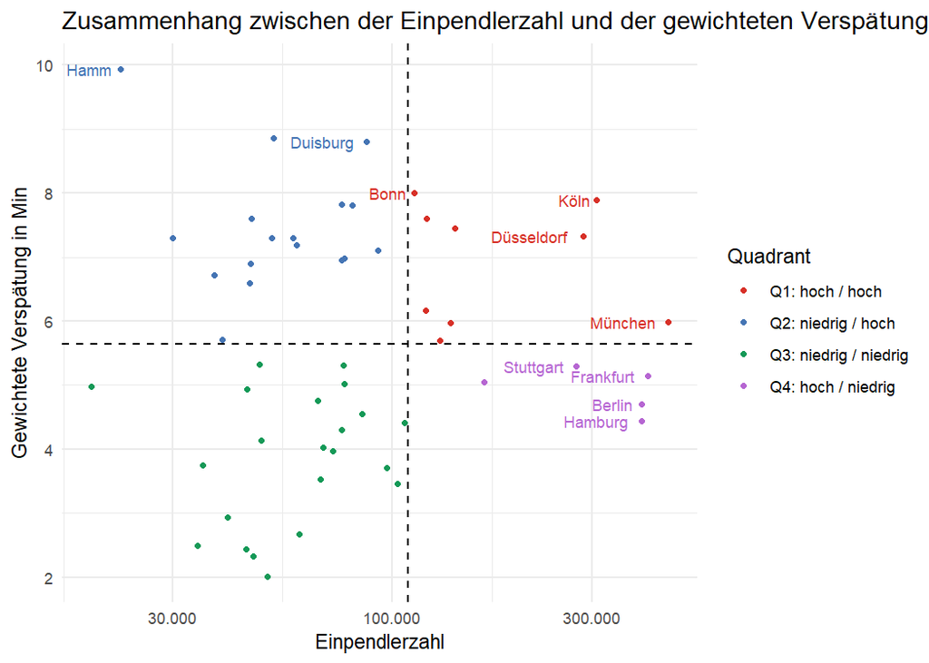

**Beschreibung, Interpretation**

Das Streudiagramm zeigt den Zusammenhang zwischen der Anzahl der Einpendler und der gewichteten Verspätung. Auf der x-Achse wird die Zahl der Einpendler dargestellt und auf der y-Achse die gewichtete Verspätung in Minuten. Jeder Punkt steht für eine Stadt, wobei nur die Top zehn Städte mit dem höchsten Problem-Score beschriftet wurden. Die Grafik ist in vier Quadranten unterteilt, die unterschiedliche Risikostufen anzeigen. Farblich sind die Punkte nach Risikostufe unterschieden.

Oben rechts (Viele Pendler + hohe Verspätung): Dieser Quadrant zeigt Städte wie Bonn, Köln, Düsseldorf oder München, in denen sowohl viele Pendler unterwegs sind als auch die Züge eine hohe Verspätung aufweisen. Dieser Quadrant kann als kritischer Quadrant betrachtet werden, da hier besonders hoher Handlungsbedarf besteht. Maßnahmen zur Reduzierung der Unzufriedenheit sind beispielsweise Pünktlichkeitsmaßnahmen oder auch Kapazitätserweiterungen.

Oben links (Wenige Pendler + hohe Verspätung): In diesem Quadranten sind die Einpendlerzahlen zwar gering, die Verspätung jedoch hoch. Demnach deutet dies darauf hin, dass es strukturelle Probleme oder auch ineffiziente Abläufe gibt. Der Handlungsbedarf ist hier nicht so hoch wie im kritischen Quadranten (Q1), es gibt jedoch Optimierungspotenzial. Betroffene Städte sind beispielsweise Hamm und Duisburg.

Unten rechts (Viele Pendler + niedrige Verspätung): Hier sind viele Pendler unterwegs, die Verspätungen sind jedoch vergleichsweise gering. In diesem Quadranten befinden sich Städte wie Stuttgart, Frankfurt, Berlin und Hamburg. Dies zeigt, dass diese Strecken auch bei einer hohen Auslastung gut funktionieren. Für andere Problemstrecken können sie als Vorbild dienen, auch wenn hier kleine Verbesserungen weiterhin sinnvoll sind.

Unten links (Wenige Pendler + niedrige Verspätung): Der Quadrant ist durch eine geringe Pendleranzahl und niedrige Verspätungen gekennzeichnet. Da hier sowohl die Nachfrage als auch die Verspätungen niedrig sind, ist der Handlungsdruck relativ gering. Maßnahmen können optional für die Verbesserung getroffen werden.

*Warum ist es sinnvoll die x-Achse zu logarithmieren?*

Es ist sinnvoll, die x-Achse zu logarithmieren, da die Einpendlerzahl zwischen den Städten stark variiert. Durch eine logarithmierte x-Achse wird die Darstellung übersichtlicher, und die Städte lassen sich besser miteinander vergleichen.

*Welche Städte liegen im kritischen Quadranten?*

Wie bereits erwähnt, kann Q1 als kritischer Quadrant bezeichnet werden, da hier sowohl die Pendlerzahlen als auch die gewichteten Verspätungen hoch sind. Unter den zehn Städten mit dem höchsten Problem-Score befinden sich hier Bonn, Düsseldorf, Köln und München.

*Was würden Sie der Deutschen Bahn empfehlen?*

Die erste Priorität sollte auf dem kritischen Quadranten liegen. Hier sollte die Deutsche Bahn insbesondere Maßnahmen zur Pünktlichkeit der Züge ergreifen, beispielsweise durch Kapazitätserweiterungen und Infrastrukturmaßnahmen, um vor allem Engpässe zu beseitigen.

In Städten mit geringer Pendlerzahl, aber hohen Verspätungen, sollte vor allem die Prozessorganisation optimiert werden. Eine effizientere Planung und Organisation könnte die Verspätungen deutlich reduzieren.

In weniger kritischen Städten wie in Q3, in denen sowohl die Pendlerzahl als auch die gewichteten Verspätungen niedrig sind, besteht nur wenig Handlungsbedarf. Hier ist es hauptsächlich wichtig, den jetzigen Standard zu halten, sodass kleine kontinuierliche Anpassungen genügen.

Der Quadrant Q4 zeigt, dass trotz hoher Pendlerzahlen geringe Verspätungen möglich sind. Demnach kann er als Vorbild für Städte wie München, Düsseldorf und Köln dienen.

# Der Vergleich – Auto vs. Bahn

Sie haben nun identifiziert, **wo** die Bahn Probleme hat: Städte im kritischen Quadranten (viele Pendler + hohe Verspätungen) brauchen dringend Verbesserungen. Aber bevor Sie Empfehlungen aussprechen können, müssen Sie eine zentrale Frage beantworten:

> **Lohnt sich die Bahn überhaupt – oder ist das Auto trotz Stau schneller?**

Denn selbst wenn die Bahn unpünktlich ist, könnte sie immer noch schneller sein als das Auto im Berufsverkehr. Umgekehrt: Eine pünktliche Bahn bringt wenig, wenn das Auto trotzdem schneller ist. Erst der **direkte Vergleich** zeigt uns, wo die Bahn wirklich konkurrenzfähig ist – und wo nicht.

## Methodische Herausforderungen

Für einen fairen Vergleich sollten Sie “Äpfel mit Äpfeln” vergleichen:

- Beim **Auto** muss der Stau berücksichtigt werden (nicht nur die theoretische Fahrzeit)
- Bei der **Bahn** muss die Verspätung berücksichtigt werden (nicht nur der Fahrplan)
- Beide Routen müssen **dieselben Start- und Endpunkte** haben

Für die Auto-Fahrtzeiten nutzen Sie **OSRM** (Open Source Routing Machine), das auf OpenStreetMap-Daten basiert. OSRM berechnet echte Straßenrouten, keine Luftlinien.

11. Erklären Sie in eigenen Worten:
- Warum ist OSRM-Routing für diesen Vergleich besser geeignet als eine einfache Berechnung nach der Formel `Distanz / Geschwindigkeit`?
- Welche Faktoren müssen zusätzlich berücksichtigt werden, um einen realistischen Vergleich zu ermöglichen? Denken Sie an:
  - Tageszeit
  - Parkplatzsuche
  - Fußweg zum Ziel
  - Wartezeit und Umsteigen bei der Bahn

**Warum ist OSRM-Routing für diesen Vergleich besser geeignet als eine einfache Berechnung nach der Formel `Distanz / Geschwindigkeit`?**

Die einfache Formel v = s/t (Geschwindigkeit = Distanz/Zeit) ist für die Verkehrsplanung unzureichend, da sie von einer idealisierten Luftlinie und einer konstanten Durchschnittsgeschwindigkeit ausgeht. Das OSRM-Routing bietet hingegen entscheidende Vorteile für einen realitätsnahen Vergleich:

Das OSRM-Routing nutzt reale Karten von OpenStreetMap, dadurch fließen im Gegensatz zur Luftlinie wichtige Informationen wie Einbahnstraßen, Autobahnen, Kreisverkehre sowie Ampelschaltungen in die Berechnungen mit ein. Da Hindernisse wie Flüsse oder Bahngleise Umwege erzwingen, ist die reale Fahrtstrecke oft 20–30 % länger als die mathematische Distanz. Ein weiterer Vorteil von OSRM ist die Unterscheidung zwischen verschiedenen Straßentypen (Autobahn, Landstraße, Tempo-30-Zone), denn nicht jeder Kilometer wird gleich schnell zurückgelegt. Während die einfache Formel eine fiktive Durchschnittsgeschwindigkeit annimmt, erkennt OSRM, dass die Reisegeschwindigkeit in urbanen Wohngebieten drastisch sinkt.

Durch die Verknüpfung mit Ampelschaltungen und Kreuzungspunkten liefert OSRM eine fundierte Basiszeit, die weit über eine einfache Schätzung hinausgeht.

**Welche Faktoren müssen zusätzlich berücksichtigt werden, um einen realistischen Vergleich zu ermöglichen?**

Um die Bahn mit dem Auto direkt vergleichen und die Frage, ob die Bahn sich lohnt, realistisch beantworten zu können, müssen einige Faktoren zusätzlich berücksichtigt werden.

Tageszeit und Verkehrsaufkommen (Stau-Faktor):  
Das Auto ist nachts fast immer schneller. Ein fairer Vergleich muss jedoch die Hauptverkehrszeiten (HVZ) abbilden. Hier zeigt sich die Stärke der Bahn: Während das Auto im Berufsverkehr oft nur noch mit 15–20 km/h vorankommt (Stau), nutzt die Bahn eigene Trassen. OSRM-Daten müssen daher mit Stau-Indizes (wie von INRIX) gewichtet werden, um die “verlorene Zeit” im Berufsverkehr korrekt darzustellen.

Parkplatzsuche:  
Ein Autofahrer ist nicht am Ziel, wenn er das Gebäude erreicht, sondern wenn das Auto geparkt ist. In Städten wie München oder Frankfurt kann die Parkplatzsuche und der anschließende Fußweg zum Büro 10 bis 15 Minuten zusätzliche Zeit beanspruchen. Diese Zeit muss zur Auto-Fahrzeit addiert werden.

Fußwege:  
Um einen realistischen Vergleich zu ermöglichen, müssen auch die Fußwege zum Ziel berücksichtigt werden. Da man mit dem Auto zumeist bis kurz vor seinem gewünschten Endpunkt fahren kann, stellt dies einen Zeitvorteil für das Auto dar. Bei der Bahn beginnt die Reise nicht am Gleis. In einen realistischen Vergleich müssen die Fußwege zum Bahnhof sowie vom Zielbahnhof zum endgültigen Endpunkt eingerechnet werden.

Wartezeit und Umsteigen bei der Bahn:  
Ein Fahrplan ist eine Idealvorstellung. In der Realität entstehen Pufferzeiten beim Umsteigen. Wenn ein Anschlusszug verpasst wird, verdoppelt sich die Reisezeit oft. Auch die Taktdichte spielt eine Rolle: Muss ein Pendler 20 Minuten auf den nächsten Zug warten, verschlechtert dies die Konkurrenzfähigkeit der Bahn massiv, selbst wenn der Zug an sich schnell fährt.

12. Für die Top 10 Einpendler-Städte wurden typische Pendlerstrecken definiert (z.B. Dachau $\rightarrow$ München, Neuss $\rightarrow$ Düsseldorf). Die OSRM-Ergebnisse liegen bereits vor. Nutzen Sie für ihre Analyse den Datensatz `fahrtzeit`.

Erstellen Sie:

- Eine **Tabelle** mit: Stadt, Strecke, Distanz (km), Auto-Fahrzeit (Hauptverkehrszeit), Bahn-Fahrzeit (real), Differenz
- Berechnen Sie die **jährliche Zeitersparnis** bei 220 Arbeitstagen und 2x täglichem Pendeln.

Interpretieren Sie ihre Tabelle:

- In wie vielen Fällen ist die Bahn schneller als das Auto?
- Wie viele Stunden pro Jahr kann ein Pendler maximal sparen?
- Gibt es Strecken, bei denen das Auto schneller ist? Woran könnte das liegen?

Fahrtzeitvergleich Auto vs. Bahn auf den Hauptrouten der Top 10 Pendlerstädte

| Stadt | Strecke | Distanz [km] | Auto-Fahrzeit (HVZ) [min] | Bahn-Fahrzeit (real) [min] | Differenz [min] | Ersparnis [h/Jahr] |
| --- | --- | --- | --- | --- | --- | --- |
| Berlin | Potsdam → Berlin | 34,2 | 49,3 | 29,6 | 19,7 | 144,6 |
| München | Dachau → München | 19,1 | 40,2 | 26,1 | 14,1 | 103,5 |
| Hannover | Celle → Hannover | 42,2 | 54,4 | 40,8 | 13,6 | 99,8 |
| Frankfurt | Darmstadt → Frankfurt | 36,0 | 35,8 | 23,0 | 12,8 | 93,9 |
| Düsseldorf | Neuss → Düsseldorf | 12,1 | 27,1 | 17,1 | 10,0 | 73,3 |
| Hamburg | Harburg → Hamburg | 14,2 | 24,0 | 16,3 | 7,7 | 56,7 |
| Stuttgart | Esslingen → Stuttgart | 14,0 | 27,2 | 20,2 | 7,0 | 51,6 |
| Nürnberg | Fürth → Nürnberg | 10,4 | 18,9 | 12,9 | 6,0 | 44,4 |
| Köln | Leverkusen → Köln | 18,3 | 28,7 | 22,8 | 5,9 | 43,3 |
| Essen | Mülheim → Essen | 11,0 | 18,0 | 15,3 | 2,7 | 20,1 |

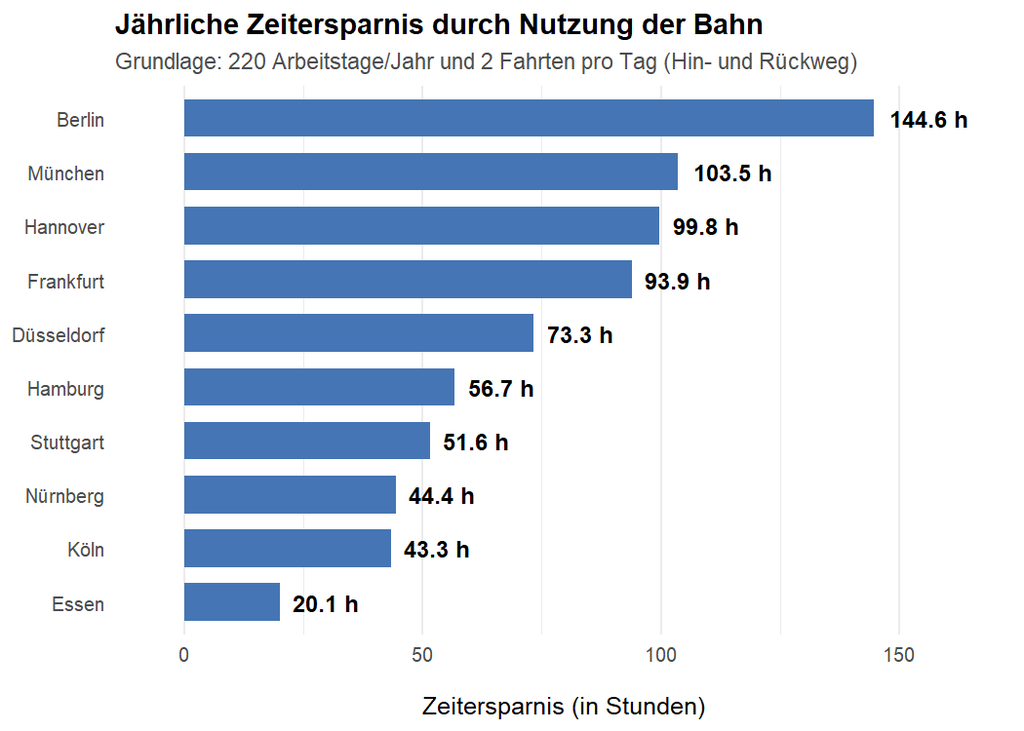

**Interpretation**

Allgemein verdeutlicht der Vergleich, dass die Bahn auf allen untersuchten Pendlerrouten eine konkurrenzfähige bzw. überlegene Alternative zum Auto darstellt. Trotz der Berücksichtigung realer Verspätungszeiten im Bahnverkehr erweist sich die Bahn in den Top-10 Einpendler-Städten als zeiteffizienter, da sie nicht von der Verkehrsüberlastung auf den Straßen während der Hauptverkehrszeit betroffen ist.

*In wie vielen Fällen ist die Bahn schneller als das Auto?*  
In allen 10 untersuchten Fällen ist die Bahn schneller als das Auto in der Hauptverkehrszeit. Dies betrifft die Pendlerstrecken nach München, Frankfurt, Hamburg, Berlin, Köln, Düsseldorf, Stuttgart, Nürnberg, Essen und Hannover. Dies belegt, dass die Bahn auf den wichtigsten Pendlerstrecken in Deutschland trotz ihrer eigenen Unpünktlichkeit einen zeitlichen Vorsprung gegenüber dem Autoverkehr behaupten kann, da dieser durch Stauzeiten in der Hauptverkehrszeit ausgebremst wird. Es zeigt sich zudem ein klares Muster: Längere Pendlerstrecken und dichtere urbane Kerne vergrößern den Zeitvorteil der Bahn. Während das Auto in Berlin im Stau fast 50 Minuten benötigt, bewältigt die Bahn dieselbe Strecke unter Realbedingungen in knapp unter 30 Minuten. Das Balkendiagramm visualisiert genau diese Zeitersparnis durch lange blaue Balken für alle Standorte.

*Wie viele Stunden pro Jahr kann ein Pendler maximal sparen?*  
Ein Pendler kann maximal 144,6 Stunden pro Jahr an Zeitersparnis haben. Dieser Spitzenwert ergibt sich auf der Strecke Potsdam -> Berlin, wo die Bahn pro Einzelfahrt 19,7 Minuten schneller ist als das Auto während der Hauptverkehrszeit. Auf das Jahr gerechnet - bei 220 Arbeitstagen und zwei Fahrten pro Tag - entspricht dies einer Ersparnis von ungefähr 18 vollen Arbeitstagen bei einem 8-Stunden-Alltag. Grund dafür ist die hohe Staudichte auf den Berliner Stadtautobahnen (AVUS) und Zubringern, welche zu massiven Verzögerungen beim Auto führen. Währenddessen verbindet die Schienenverbindung (Regionalbahn/S-Bahn) Berlin und Potsdam auf einer leistungsfähigen, vom Straßenverkehr getrennten Trasse. Auch in München (103,5 h) und Hannover (99,8) ist die Zeitersparnis enorm. In Städten wie Essen oder Köln ist die Netto-Ersparnis mit 20,1 h bzw. 43,3 h deutlich geringer. Hier zeigt sich, dass die Bahn zwar schneller bleibt, ihr systemimmanenter Geschwindigkeitsvorteil jedoch fast vollständig durch die hohen Verspätungswerte (z. B. 7,3 Min. in Essen oder 7,8 Min. in Köln) verloren geht.

*Gibt es Strecken, bei denen das Auto schneller ist? Woran könnte das liegen?*  
In der Auswahl der Top 10 Einpendlerstädte gibt es keine einzige Strecke, auf der das Auto schneller ist. Selbst in Essen, wo der Zeitvorteil der Bahn mit 2,7 Minuten pro Fahrt am geringsten ausfällt, summiert sich dies auf über 20 Stunden pro Jahr. Dass das Auto auf keiner dieser Routen schneller ist, liegt an mehreren Faktoren: Zum einen nutzen Bahnen eigene Gleistrassen. Während das Auto im Berufsverkehr physisch durch die Kapazitätsgrenze der Straße limitiert wird (Stau), kann die Bahn ihre Reisegeschwindigkeit unabhängig vom Verkehrsaufkommen auf der Straße halten. Vor allem in den aufgezählten Top-10 Einpendlerstädten ist das Straßennetz zu den Stoßzeiten chronisch überlastet, weshalb die verlorene Zeit im Stau die durchschnittliche Bahnverspätungen in diesen Regionen deutlich übersteigt. Zudem liegen die gewählten Strecken (z.B. Celle → Hannover oder Dachau → München) in einem Distanzbereich (ca. 10–40 km), der lang genug ist, damit die Bahn ihre höhere Durchschnittsgeschwindigkeit ausspielen kann, aber kurz genug, damit die Umstiegs- und Pufferzeiten nicht zu schwer ins Gewicht fallen.

13. Da Sie alle in Ulm studieren und eventuell aus dem Ulmer Umland einpendeln, sollten Sie die **5 wichtigsten Pendlerrouten nach Ulm** näher analysieren. Stellen Sie in einem **Dumbbell-Chart** (oder Lollipop-Chart) die Unterschiede zwischen Auto- und Bahnzeiten visuell dar. Nutzen Sie für ihre Analyse den Datensatz `ulm_routen`.

Die 5 wichtigsten Pendlerrouten nach Ulm sind:

- Neu-Ulm $\rightarrow$ Ulm
- Blaustein $\rightarrow$ Ulm
- Ehingen $\rightarrow$ Ulm
- Laupheim $\rightarrow$ Ulm
- Langenau $\rightarrow$ Ulm

Markieren Sie, welche Orte **keinen Bahnhof** haben.

Beschreiben und interpretieren Sie ihre Grafik. Welche Besonderheiten zeigen die ländlichen Strecken?

*Hinweis:* Nutzen Sie `geom_segment()` und `geom_point()` für ihr [Dumbbell-Chart](https://r-graph-gallery.com/web-dumbbell-chart-with-a-gap-column.html) oder [Lollipop-Chart](https://r-graph-gallery.com/303-lollipop-plot-with-2-values.html).

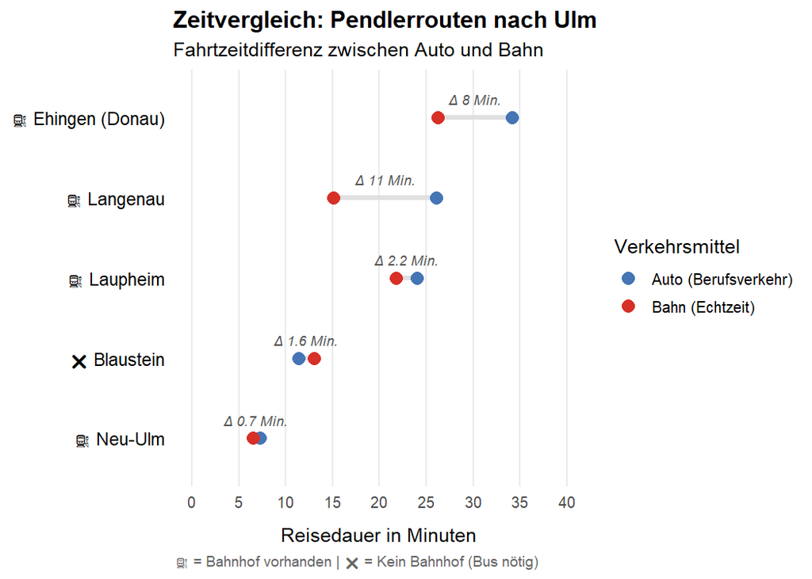

**Beschreibung**

Die grafische Darstellung der fünf wichtigsten Pendlerrouten nach Ulm erfolgt mithilfe eines sogenannten Dumbbell-Charts, welches den unmittelbaren Vergleich von zwei korrespondierenden Zeitwerten ermöglicht. Auf der y-Achse sind die Startpunkte der Pendlerrouten dargestellt, wobei die Sortierung absteigend nach der Fahrzeit mit dem Auto zur Hauptverkehrszeit erfolgt, sodass die zeitintensivsten Strecken oben am Ende der Grafik stehen. Jedem Ortsnamen ist dabei ein spezifisches Icon vorangestellt: Ein Bahnhof-Symbol markiert Orte, die einen Bahnhof haben, während ein Kreuz auf das Fehlen eines Bahnhofs hinweist. In diesem Vergleich ist Blaustein der einzige der abgebildeten Orte ohne einen eigenen Bahnhof. Die x-Achse bildet die Reisedauer in einer Skala von 0 bis 40 Minuten ab, wobei feine Hilfslinien in 5-Minuten-Intervallen das präzise Ablesen der Werte unterstützen. Innerhalb der Grafik zeigen die farbigen Punkte die jeweiligen Realfahrzeiten an, wobei Blau die Fahrzeit mit dem Auto zur Hauptverkehrszeit und Rot die Bahn unter Echtzeitbedingungen repräsentiert. Die hellgrauen Verbindungssegmente zwischen diesen Punkten verdeutlichen die zeitliche Differenz. Zusätzlich zeigen die Daten-Labels über den Verbindungssegmenten die exakte Minutendifferenz zwischen Auto und Bahn an.

**Interpretation**

Aus der Grafik lässt sich erkennen, dass der Schienenverkehr auf den längeren Strecken deutlich dominiert, was insbesondere auf der Route Langenau -> Ulm sichtbar wird. Hier erzielen Bahnpendler mit einer Ersparnis von 11 Minuten den größten Zeitvorteil, da die Bahn auf dieser Distanz fast doppelt so schnell ist wie das Auto zur Hauptverkehrszeit. Im Gegensatz dazu sind die Unterschiede auf Kurzstrecken wie der Verbindung Neu-Ulm -> Ulm mit einer Differenz von lediglich 0,7 Minuten vernachlässigbar gering. Eine signifikante Ausnahme bildet die Route Blaustein -> Ulm, welche als einzige einen Zeitvorteil von 1,6 Minuten zugunsten des Autos aufweist. Dies korreliert direkt mit dem fehlenden Bahnhofsanschluss vor Ort. Denn die Umstiege auf den Bus oder längere Fußwege führen zu zusätzlichen Zeitverlusten. Aufgrund dessen erweist sich das Auto trotz der hohen Verkehrsbelastung als die effizientere Option.

*Welche Besonderheiten zeigen die ländlichen Strecken*

Besonders bei den ländlichen Strecken wie Langenau und Ehingen zeigen die Daten interessante Ergebnisse. Entgegen der häufigen Annahme, dass der ländliche Raum auf das Auto angewiesen ist, weisen gerade diese Verbindungen die größten Zeitersparnisse durch die Bahn auf. Denn während die Straßen im Berufsverkehr oft überlastet sind, bietet die Bahn eine deutlich schnellere Verbindung nach Ulm.

# Die volkswirtschaftlichen Kosten

Verspätungen kosten nicht nur Nerven, sie haben einen **realen volkswirtschaftlichen Preis**. Jede Minute, die ein Pendler im verspäteten Zug wartet, ist verlorene Arbeitszeit.

Um diese Kosten etwas besser zu quantifizieren sollten Sie sich den **Medianlohn** der jeweiligen Städte herunterladen und näher analysieren.

14. Berechnen Sie die volkswirtschaftlichen Kosten der Bahnverspätungen für die 11 Städte.

**Datensätze:**

- `staedte_basis` (aus Aufgabe 4) – enthält Einpendler, Medianlohn und Staudaten
- Ergebnis aus Aufgabe 9: die **gewichtete durchschnittliche Verspätung pro Stadt** (in Minuten)

Nutzen Sie die folgenden Annahmen:

**Annahmen:**

- 220 Arbeitstage pro Jahr
- 2 Fahrten pro Tag (Hin + Zurück)
- Ca. 8,4% der Pendler nutzen die Bahn (nationaler Durchschnitt laut [MiD 2023 Kurzbericht](https://www.mobilitaet-in-deutschland.de/pdf/MiD2023_Kurzbericht.pdf))

Berechnen Sie für jede Stadt:

- Anzahl der Bahnpendler (Einpendler × 8,4%)
- Verspätungsstunden pro Jahr (Verspätung × 220 × 2 / 60)
- Kosten pro Pendler (Verspätungsstunden × Stundenlohn)
- Gesamtkosten der Stadt

Erstellen Sie auf Basis ihrer Berechnung eine Tabelle, welche die Anzahl der Bahnpendler, die Verspätungsstunden pro Jahr, die Kosten pro Pendler und die Gesamtkosten der Stadt anschaulich darstellt.

Beschreiben und interpretieren Sie ihre Tabelle. Gehen Sie dabei auch auf die Gesamtkosten der 11 Städte ein. Erklären Sie außerdem, warum der **Medianlohn** für diese Berechnung besser geeignet ist als der Durchschnittslohn.

*Hinweis:* Für die Umrechnung auf Stundenlohn: Monatsentgelt / 160 (bei 40h/Woche).

Volkswirtschaftliche Kosten durch Bahnverspätungen (Top 10 Städte und Ulm)

| Stadt | Einpendler | Bahnpendler | Verspätung (h/Jahr) | Kosten/Pendler (€) | Gesamtkosten der Stadt (Mio. €) |
| --- | --- | --- | --- | --- | --- |
| München | 455.645 | 38.274 | 43,86 | 1.328,78 | 50,86 |
| Köln | 306.905 | 25.780 | 57,87 | 1.590,62 | 41,01 |
| Frankfurt am Main | 405.856 | 34.092 | 37,73 | 1.111,06 | 37,88 |
| Düsseldorf | 284.696 | 23.914 | 53,77 | 1.519,95 | 36,35 |
| Hamburg | 392.951 | 33.008 | 32,59 | 922,13 | 30,44 |
| Berlin | 392.324 | 32.955 | 34,47 | 895,47 | 29,51 |
| Stuttgart | 274.442 | 23.053 | 38,85 | 1.138,56 | 26,25 |
| Essen | 141.296 | 11.869 | 54,62 | 1.361,04 | 16,15 |
| Nürnberg | 165.496 | 13.902 | 37,06 | 980,73 | 13,63 |
| Region Hannover | 137.924 | 11.586 | 43,81 | 1.137,85 | 13,18 |
| Ulm | 68.341 | 5.741 | 29,51 | 795,32 | 4,57 |

**Beschreibung**

Die Tabelle “Volkswirtschaftliche Kosten durch Bahnverspätungen (Top 10 Städte und Ulm)” stellt die jährlichen volkswirtschaftlichen Kosten dar, die durch Verspätungen im Bahnverkehr in den elf untersuchten Städten entstehen. Die Berechnung basiert auf der Annahme von 220 Arbeitstagen pro Jahr, zwei Fahrten pro Tag und einem durchschnittlichen Anteil von 8,4 % Bahnpendlern unter den Einpendlern. In den Spalten werden für alle elf Städte die Anzahl der Einpendler, die Anzahl der Bahnpendler, die Verspätungsstunden pro Jahr, die Kosten pro Pendler, sowie die Gesamtkosten der Stadt aufgeführt. Die Tabelle ist absteigend nach den Gesamtkosten sortiert, wobei München mit Gesamtkosten von 50.857.695 € die höchsten Kosten aufweist.

**Interpretation**

*Warum ist der Medianlohn für diese Berechnung besser geeignet als der Durchschnittslohn?*

In der Statistik ist der Medianlohn deutlich aussagekräftiger als der Durchschnittslohn, wenn es um die Abbildung der breiten Bevölkerung geht. Der Durchschnitt wird durch extrem hohe Gehälter - die Spitzenverdiener - nach oben verzerrt und liegt dadurch meist über dem Einkommen, das die breite Mehrheit der Bevölkerung tatsächlich bezieht. Der Median hingegen teilt die Gruppe genau in der Mitte: 50 % verdienen mehr, 50 % verdienen weniger. Er repräsentiert somit den „typischen“ Pendler wesentlich realistischer und ist weniger anfällig für statistische Ausreißer.

15. Setzen Sie die Kosten der Bahn (aus Aufgabe 14) den Kosten des Autos gegenüber. Vergleichen Sie diese in einer Szenario-Analyse mittels eines gestapelten Balkendiagramms. Nutzen Sie für ihre Analysen den Datensatz `staedte_basis`.

Berechnen Sie zuerst die Kosten des Autostaus pro Stadt:

- Anzahl der Autopendler (Einpendler × 91,6%)
- Staukosten pro Autopendler (Staustunden × Stundenlohn)
- Gesamtkosten der Stadt durch Autostau

Führen Sie anschließend einen Szenario-Vergleich durch: Was passiert, wenn der Bahnanteil von 8,4% auf 20% steigt?

- Berechnen Sie die Gesamtkosten (Bahn + Auto) für beide Szenarien
- *Annahme:* Weniger Autos = weniger Stau (z.B. 20% weniger Stauzeit pro Autopendler)

Erstellen Sie ein gestapeltes Balkendiagramm nach Szenario. Beschreiben und intepretieren Sie ihre Grafik. Gehen Sie insbesondere auf die folgenden Fragen ein:

- Wie verteilen sich die Kosten zwischen Bahn und Auto im Status quo?
- Welches Verkehrsmittel verursacht den größeren volkswirtschaftlichen Schaden?
- Was ist die Nettoersparnis bei 20% Bahnanteil?

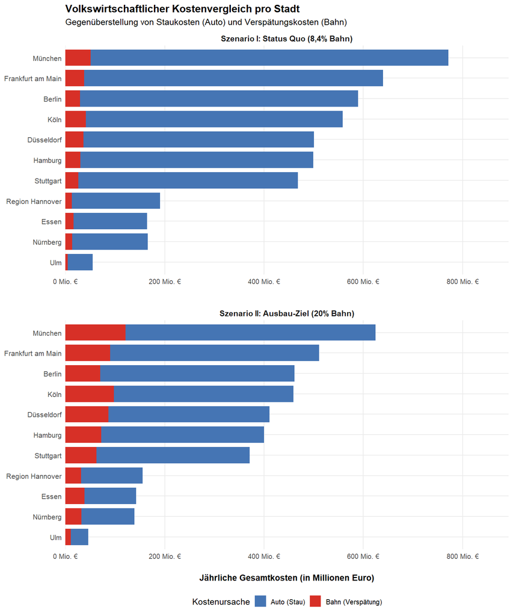

**Beschreibung**

Die vorliegende Szenario-Analyse visualisiert den volkswirtschaftlichen Kostenvergleich zwischen dem aktuellen Stand (Status Quo) und einem potenziellen Ausbau-Szenario für elf deutsche Pendler-Metropolen. Auf der y-Achse sind die untersuchten Städte aufgeführt, während die x-Achse die jährlichen Gesamtkosten in Millionen Euro quantifiziert. Die Darstellung erfolgt in Form von gestapelten Balken: Der blaue Anteil visualisiert die volkswirtschaftlichen Verluste durch Zeitverzögerungen im Autostau, während der rote Anteil die Kosten durch Bahnverspätungen abbildet. Das obere Diagramm repräsentiert den Status Quo (8,4 % Bahnanteil), das untere das Ziel-Szenario (20 % Bahnanteil bei gleichzeitiger Entlastung des Straßennetzes).

**Interpretation**

Die Analyse zeigt, welches enorme Einsparungspotenzial in einem Ausbau des Bahnanteils auf 20% steckt.

*Welches Verkehrsmittel verursacht den größeren volkswirtschaftlichen Schaden?*  
Das Auto ist eindeutig der größere Kostenverursacher. Dies liegt zum einen an der großen Masse (über 90 % der Pendler nutzen das Auto) und zum anderen daran, dass die jährlichen Staustunden pro Kopf in vielen Städten sogar über den durchschnittlichen Verspätungsstunden der Bahn liegen.

*Zusammenfassend lässt sich festhalten:*  
Für Pendler in den deutschen Großmetropolen ist die Bahn trotz der häufigen Bahnverspätungen unter dem reinen Zeitaspekt die überlegene Wahl gegenüber dem Auto.

# Politikempfehlung – Ihre Synthese

Sie haben nun umfangreiche Analysen durchgeführt und viele Erkenntnisse über die Bahn gewonnen. Jetzt ist es Zeit, diese zu einer **kohärenten Empfehlung** zusammenzufügen.

**Szenario:** Sie sind Berater:in des Bundesministeriums für Digitales und Verkehr. Die Ministerin bittet Sie um eine evidenzbasierte Politikempfehlung zur Verbesserung des Pendlerverkehrs in Deutschland.

16. Formulieren Sie eine **Politikempfehlung** für das Bundesministerium für Digitales und Verkehr.

Schreiben Sie eine **Executive Summary (max. 5 Sätze)**. Fassen Sie hierbei die wichtigsten Erkenntnisse aus ihrem Projekt zusammen. Was ist die zentrale Botschaft?

Formulieren Sie 3 konkrete Empfehlungen. Jede muss enthalten:

- Ein konkretes **Ziel** (Was soll erreicht werden?)
- Eine messbare **Maßnahme** (Wie wird es umgesetzt?)
- Eine **Begründung mit Zahlen** aus Ihrer Analyse
- Nennen Sie **zwei Limitationen** Ihrer Datengrundlage
- Was würden Sie mit **zusätzlichen Daten** noch untersuchen?

**Politikempfehlung**

*Executive Summary:*

Das Projekt zeigt, dass der deutsche Pendlerverkehr trotz Bahnverspätungen im Vergleich zu den volkswirtschaftlichen Kosten des Autoverkehrs weiterhin deutlich effizienter ist. Demnach werden 90% der Gesamtkosten nicht durch die Bahn, sondern durch Staus der Autos verursacht. Besonders in Städten des kritischen Quadranten wie beispielsweise München, Köln und Düsseldorf treffen hohe Pendlerzahlen auf hohe Verspätungen, was zu einem hohen Problem-Score (Handlungsbedarf) führt. Zusätzlich hat sich auch herausgestellt, dass die Bahn in 10 von 10 untersuchten Fällen schneller als das Auto in der Hauptverkehrszeit ist. Dies kann Pendlern bis zu 144 Stunden Zeit pro Jahr einsparen. Insgesamt zeigt die Analyse, dass Investitionen in einen zuverlässigen, pendlerfreundlichen Bahnverkehr ökonomisch sinnvoller sind, als den weiteren Ausbau des Autoverkehrs.

*Empfehlung 1: Stabilisierung des Bahn-/Nahverkehrs:*

Ziel ist die Reduzierung von Verspätungen im Bahn- und Nahverkehr, insbesondere während der Hauptverkehrszeiten. Betroffene Städte sind München, Köln, Düsseldorf oder Bonn, die alle im kritischen Quadranten liegen. In diesen Städten kommt es zu hohen Pendlerzahlen und gleichzeitig treten hohe Verspätungen auf, weshalb sie einen besonders hohen Problem-Score (Handlungsbedarf) aufweisen (München: 3,45).

Als Maßnahme sollte vor allem die Infrastruktur in Engpässen ausgebaut werden. Eine Möglichkeit sind zusätzliche Gleise, sodass Überholungen ermöglicht werden, oder auch die Gestaltung realistischer Fahrpläne mit eingebauten Pufferzeiten. Die Wirksamkeit lässt sich messen durch die Überprüfung der durchschnittlichen Verspätung im Nahverkehr. Demnach ist die Maßnahme erfolgreich, wenn sich Verspätungen von über 5 Minuten auf unter 3 Minuten reduzieren.

Begründung: Besonders der Nahverkehr trägt den Großteil des Pendlereinkommens. Alleine die S-Bahn verzeichnet über 6,4 Millionen Halte pro Monat. Auch wenn die Verspätungen mit 2,9 Minuten gering erscheinen, verursachen bereits kleine Verzögerungen erhebliche Zeitverluste und hohe volkswirtschaftliche Kosten.

In der Datengrundlage kommt es jedoch zu Limitationen. Die Analyse basiert lediglich auf einem Monat (November 2025), sodass saisonale Effekte nicht berücksichtigt werden. Zudem gibt es keine Informationen über die tatsächliche Fahrgastzahl pro Zug, sodass die Verspätungen möglicherweise nicht korrekt nach den betroffenen Personen gewichtet wurden.

Mit zusätzlichen Informationen über die Fahrgastzahlen und Engpassanalysen könnte man feststellen, wo die größten Verspätungspotenziale für die meisten Pendler entstehen.

*Empfehlung 2: Attraktivität der Bahn steigern*

Ziel ist es, die Bahn als echte Alternative zum Auto anzubieten, um die Pendlerzahl zu erhöhen und mehr Pendler auf den Schienenverkehr zu verlagern.

Maßnahmen sollten der Ausbau von Bahnstrecken durch neue Haltepunkte, die Wiedereröffnung stillgelegter Bahnhöfe und eine Erhöhung der Anzahl an Fahrten sein. Ein Erfolg ist deutlich zu erkennen, falls die Pendlerzahl auf den entsprechenden Strecken steigt und gleichzeitig die Reisezeit im Vergleich zum Auto deutlich sinkt.

Begründung: In der Analyse erkennt man, dass die Bahn auf langen Strecken in den Hauptverkehrszeiten oft schneller ist als das Auto. Auf der Strecke Potsdam–Berlin spart die Bahn bis zu 19,7 Minuten pro Fahrt. Die Strecke Blaustein–Ulm zeigt hingegen, dass Vorteile verloren gehen, wenn keine Haltestelle direkt vorhanden ist. Demnach ist vor allem der Ausbau der Schieneninfrastruktur entscheidend.

Auch für diese Maßnahme existieren jedoch Beschränkungen in der Datengrundlage. Die Ereignisse lassen sich nicht auf alle Regionen übertragen, da nur bestimmte Strecken ausgewählt wurden. Faktoren wie Umstiegszeiten oder die Anfahrt an den Bahnhof mit Bussen etc. wurden lediglich vereinfacht modelliert, sodass Auswirkungen nicht wirklich erkennbar sind.

Mithilfe zusätzlicher Daten kann eine genauere Analyse durchgeführt und herausgefunden werden, welche Maßnahmen den größten Zeitgewinn für Pendler bringen.

*Empfehlung 3: Echtzeitinformationen und das digitale Serviceangebot ausbauen*

Das Ziel ist es, Pendler besser über aktuelle Verspätungen, Ausfälle und alternative Verbindungen zu informieren, um die Reiseplanung stressfreier und effizienter zu gestalten, auch wenn Verspätungen auftreten sollten.

Um das Ziel zu erreichen, sollte ein Ausbau der Echtzeit-DB-App und digitaler Informationssysteme stattfinden. Diese sollen neben aktuellen Verspätungen auch alternative Routen und Anschlusszüge anzeigen. Zudem könnte auch eine automatisierte Push-Benachrichtigung den Pendlern weiterhelfen. Ob die Maßnahme erfolgreich ist, lässt sich z. B. an verkürzten Wartezeiten, der höheren Nutzung von Alternativverbindungen oder der Kundenzufriedenheit messen.

Begründung: Die Analyse zeigt, dass Verspätungen im Nahverkehr zwischen 2,9 und 5 Minuten liegen, im Fernverkehr jedoch bis zu 20 Minuten erreichen können. Durch fehlende Informationen entstehen oft zusätzliche Verzögerungen beim Umstieg. Durch genauere Echtzeitinformationen könnten sowohl wirtschaftliche Verluste als auch Zeitverluste reduziert werden.

Auch diese Maßnahme hat Limitationen in ihrer Datengrundlage. Es ist nicht bekannt, ob Pendler bei Verspätungen ihren Anschluss verpassen oder wie sie auf aktuelle Informationen reagieren, sodass keine Daten über das tatsächliche Verhalten der Pendler vorliegen. Zudem fehlen Informationen über die Nutzung bereits vorhandener Informationssysteme, sodass der Erfolg nur geschätzt werden kann.

Mit zusätzlichen Informationen über das Pendlerverhalten, genaueren Anschlusszeiten und Nutzungsmuster der DB-App könnte man untersuchen, wie Reiseverluste durch bestimmte Funktionen reduziert werden können.

# Zusatzaufgaben (optional)

Bisher haben Sie zwei Dimensionen betrachtet: **Zeit** (Bahn ist schneller) und **Geld** (Verspätungen kosten). Aber es gibt einen dritten, oft vergessenen Aspekt: die **Umwelt**.

Das Auto ist nicht nur langsamer und teurer; es ist auch ein Klimakiller. Ein durchschnittlicher PKW emittiert z.B. etwa **150 g CO2 pro Personenkilometer**.

17. Recherchieren Sie die CO2-Emissionsfaktoren und das Mobilitätsverhalten:
- Erstellen Sie eine kleine Tabelle in der Sie die CO2-Emissionen (in g/Personenkilometer) für folgende Verkehrsmittel auflisten:
  - PKW (Durchschnitt)
  - PKW (Elektro, deutscher Strommix)
  - ICE/IC (Fernverkehr)
  - RE/RB (Nahverkehr)
  - S-Bahn
- Berechnen Sie einen **gewichteten Durchschnitt** für die Bahn, wenn 70% der Pendler Nahverkehr und 30% Fernverkehr nutzen.
- Um wie viel Prozent sind die Bahn-Emissionen niedriger als beim Auto?

*Hinweis:* Nutzen Sie Daten vom Umweltbundesamt oder dem DB Umweltbericht.

CO₂-Emissionen verschiedener Verkehrsmittel 2024 (g pro Personenkilometer)

| Verkehrsmittel | CO₂ [g/Pkm] |
| --- | --- |
| PKW (Durchschnitt) | 164 |
| PKW (Elektro, deutscher Strommix) | 70 |
| ICE/IC (Fernverkehr) | 26 |
| RE/RB (Nahverkehr) | 44 |
| S-Bahn | 42 |

**Umweltwirkungen einzelner Verkehrsmittel**

Zur Bewertung der Umweltwirkungen verschiedener Verkehrsmittel werden die durchschnittlichen CO₂-Emissionen pro Personenkilometer herangezogen. Die verwendeten Emissionsfaktoren stammen aus dem Emissionsmodell TREMOD des Umweltbundesamtes [^3] und berücksichtigen neben den direkten Emissionen auch vorgelagerte Prozesse der Energiebereitstellung. Für den Schienenverkehr werden separate Emissionswerte für den Fernverkehr sowie für unterschiedliche Formen des Nahverkehrs ausgewiesen. Dies ermöglicht eine differenzierte und zugleich vereinfachte Bewertung der Emissionsintensität des Bahnverkehrs.

*Gewichteter CO₂-Durchschnitt der Bahn*

Um die durchschnittlichen Emissionen eines typischen Bahnpendlers realistisch abzubilden, wird ein gewichteter Durchschnitt berechnet. Dabei wird angenommen, dass 70 % der Pendler den Bahn-Nahverkehr und 30 % den Bahn-Fernverkehr nutzen. Der Emissionswert des Nahverkehrs ergibt sich aus dem Mittelwert der Emissionen von Regionalzügen und S-Bahnen und liegt bei rund 43 g CO₂ pro Personenkilometer. Der Fernverkehr verursacht durchschnittlich etwa 26 g CO₂ pro Personenkilometer. Unter Berücksichtigung der jeweiligen Nutzungsanteile ergibt sich für die Bahn ein gewichteter Emissionswert von rund 38 g CO₂ pro Personenkilometer.

*Vergleich von Bahn- und PKW-Emissionen*

Zum Vergleich wird der durchschnittliche CO₂-Ausstoß eines konventionellen PKW herangezogen, der laut Umweltbundesamt bei etwa 164 g CO₂ pro Personenkilometer liegt. Im Vergleich dazu fallen die Emissionen der Bahn deutlich geringer aus. Die gewichteten Emissionen des Bahnverkehrs liegen um rund 77 % unter denen eines durchschnittlichen PKW. Dieses Ergebnis verdeutlicht den erheblichen Klimavorteil des Schienenverkehrs gegenüber dem motorisierten Individualverkehr und unterstreicht dessen zentrale Rolle für eine nachhaltigere Ausgestaltung des Verkehrssektors.

18. Die Studie **“Mobilität in Deutschland” (MiD 2023)** ist die wichtigste Datenquelle zum Mobilitätsverhalten in Deutschland. Sie ermöglicht einen Vergleich mit 2017 (vor Corona).

Lesen Sie den [MiD 2023 Kurzbericht](https://www.mobilitaet-in-deutschland.de/pdf/MiD2023_Kurzbericht.pdf) und beantworten Sie:

- **Modal Split:** Wie hat sich der Anteil des öffentlichen Verkehrs (ÖV) am Gesamtverkehr zwischen 2017 und 2023 verändert?
- **Homeoffice-Effekt:** Wie hat sich die durchschnittliche Tagesstrecke verändert? Was ist laut MiD der Hauptgrund für diese Veränderung?
- **Stadt vs. Land:** Welchen Anteil hat das Deutschlandticket in Metropolen vs. ländlichen Räumen? Was bedeutet das für die Ulm-Region?
- **Implikation für CO2:** Welche Schlussfolgerung ziehen Sie aus diesen Veränderungen für das CO2-Einsparpotenzial durch Bahnpendeln? (2-3 Sätze)

**Modal Split: Veränderung des öffentlichen Verkehrs zwischen 2017 und 2023**

Der Modal Split beschreibt den Anteil verschiedener Verkehrsmittel an der Gesamtmobilität. Laut dem Kurzbericht der Studie “Mobilität in Deutschland − MiD” hat sich der Anteil des öffentlichen Verkehrs (ÖV) am Gesamtverkehr im Zeitraum von 2017 bis 2023 leicht erhöht. Im Jahr 2017 lag der Anteil des ÖV am Gesamtverkehr bei 10%, während er 2023 auf 11% anstieg. Dieser moderat steigende Anteil deutet auf eine leichte Zunahme der Nutzung von Bussen und Bahnen hin, obwohl der motorisierte Individualverkehr weiterhin den größten Teil der Wege ausmacht. Insgesamt ist der ÖV somit zwar weiterhin nicht dominierend, hat aber im Vergleich zur vorangegangenen Erhebung leicht an Bedeutung gewonnen.

**Homeoffice-Effekt: Veränderung der durchschnittlichen Tagesstrecke**

Die MiD-Studie zeigt, dass sich die durchschnittliche Tagesstrecke der Bevölkerung in Deutschland im Vergleich zu 2017 verringert hat. So gaben die Befragten für 2023 im Schnitt etwa 35 Kilometer Tagesstrecke an, während dieser Wert 2017 noch bei rund 39 Kilometern lag.

*Was ist laut MiD der Hauptgrund für diese Veränderung?*

Der Rückgang der durchschnittlichen Tagesstrecke ist laut MiD 2023 in erster Linie auf die zunehmende Nutzung von Homeoffice zurückzuführen. Die Studie zeigt deutliche Unterschiede zwischen Beschäftigten mit und ohne Homeoffice am Berichtstag: Während Personen ohne Homeoffice an Werktagen im Durchschnitt rund 60 Kilometer zurücklegen, liegt die Tagesstrecke bei Beschäftigten im Homeoffice bei etwa 20 Kilometern. Der Wegfall regelmäßiger Arbeits- und Pendelwege wirkt sich damit unmittelbar mobilitätsreduzierend aus und erklärt einen wesentlichen Teil der insgesamt geringeren Verkehrsleistung.

Online-Aktivitäten wie Einkauf oder Versorgung tragen hingegen nur in geringem Maße zur Reduktion der Mobilität bei. Zwar haben solche Aktivitäten seit 2017 deutlich zugenommen, die MiD-Ergebnisse zeigen jedoch, dass eingesparte Wege häufig durch andere außerhäusliche Aktivitäten, insbesondere im Freizeitbereich, kompensiert werden.

Insgesamt ist Homeoffice somit der zentrale Faktor für die veränderte durchschnittliche Tagesstrecke.

**Stadt vs. Land: Anteil des Deutschlandtickets**

*Der MiD 2023-Kurzbericht enthält keine detaillierte regionale Aufschlüsselung zur Nutzung des Deutschlandtickets. Für die Beantwortung dieser Fragestellung wurden daher ergänzende Daten aus der vollständigen MiD 2023-Studie* [Mobilität in Deutschland (MiD)](https://www.bmv.de/SharedDocs/DE/Artikel/G/mobilitaet-in-deutschland.html) *herangezogen.*

Demnach nutzten im Jahr 2023 in Metropolen etwa 33 % der Pendler das Deutschlandticket als ihr übliches ÖV-Ticket, während der Anteil in ländlichen Räumen bei circa 10 % liegt.

Diese Unterschiede lassen sich auf mehrere Faktoren zurückführen: In städtischen Regionen ist die Infrastruktur des ÖV dichter und leistungsfähiger, beispielsweise durch häufigere Taktungen, kürzere Wege zu Haltestellen und direktere Verbindungen. Zudem bestehen in städtischen Gebieten häufig bessere sozioökonomische Rahmenbedingungen für die Nutzung von Abonnements, während in ländlichen Räumen längere Fahrzeiten und geringere Verfügbarkeit die Nutzung hemmen.

*Was bedeutet dies für die Ulm-Region?*

Für die Ulm-Region, die sowohl städtische als auch ländliche Strukturen aufweist, ergibt sich ein mittleres Potenzial für den Umstieg vom Auto auf den ÖV. Gut angebundene Strecken ermöglichen Pendlern bereits einen Wechsel vom Auto zum öffentlichen Verkehr. Durch Maßnahmen wie Taktverdichtungen, integrierte Verkehrsangebote und Informationskampagnen lässt sich das Nutzungspotenzial des Deutschlandtickets zusätzlich steigern.

Insgesamt verdeutlichen die regionalen Unterschiede, dass die ÖV-Struktur einen zentralen Hebel für die Reduktion verkehrsbedingter CO₂-Emissionen darstellt: Dort, wo der ÖV attraktiv und zuverlässig ist, kann Pendlerverkehr effizient auf klimafreundliche Verkehrsmittel verlagert werden, während in weniger erschlossenen ländlichen Gebieten noch Infrastrukturmaßnahmen erforderlich sind, um vergleichbare Effekte zu erzielen.

**Implikation für CO₂**

*Welche Schlussfolgerung können aus diesen Veränderungen für das CO2-Einsparpotenzial durch Bahnpendeln gezogen werden?*

Die leichte Zunahme des Anteils des öffentlichen Verkehrs und die Verringerung der durchschnittlichen Tagesstrecke deuten darauf hin, dass Mobilitätsmuster sich Richtung weniger autolastiger Nutzung verschieben. In Verbindung mit einem wachsenden Anteil von ÖV‑Nutzung und flexibleren Arbeitsmodellen wie Homeoffice kann dies zu einem reduzierten CO₂‑Ausstoß im Pendlerverkehr beitragen. Eine verstärkte Nutzung von Bus und Bahn kombiniert mit reduzierten Pendeldistanzen bietet ein zusätzliches Potenzial zur Verringerung verkehrsbedingter Emissionen, insbesondere dort, wo ÖV‑Angebote gut verfügbar sind.

19. Berechnen Sie die **CO2-Ersparnis** für die 11 analysierten Städte.

**Datensatz:** `co2_analyse` (aus Aufgabe 4) – enthält Streckenlängen, Einpendlerzahlen und vorberechnete Werte

**Annahmen:**

- 220 Arbeitstage pro Jahr
- 2 Fahrten pro Tag (Hin + Zurück)
- CO2-Auto: 150 g/km, CO2-Bahn: 47 g/km (gewichteter Durchschnitt)

Berechnen Sie für **jeden Umsteiger** (Auto $\rightarrow$ Bahn):

- Jährliche Kilometer
- CO2-Emissionen mit Auto (kg/Jahr)
- CO2-Emissionen mit Bahn (kg/Jahr)
- **Ersparnis** (kg/Jahr)

Nun sollten Sie eine Szenario Analyse ähnlich wie in Aufgabe 15 durchführen: Wenn sich der Bahnanteil von 8,4% auf 20% erhöht: wie viele Tonnen CO2 würden in den 11 Städten jährlich eingespart?

Visualisieren Sie die CO2-Ersparnis pro Stadt.

Stellen Sie die Ersparnis in Kontext, um die Ersparnis greifbarer zu machen, z.B. wie viele **Mallorca-Flüge** (hin + zurück, ~750 kg CO2) entspricht das?

**CO2-Ersparnis durch den Umstieg vom Auto auf die Bahn**

*1. Ausgangssituation*

Der Pendlerverkehr trägt erheblich zum CO2-Ausstoß bei. Ein Auto verursacht durchschnittlich 150 Gramm CO2 pro Kilometer, während die Bahn nur 47 Gramm CO2 pro Kilometer ausstößt. Unter der Annahme von 220 Arbeitstagen pro Jahr und Hin- und Rückfahrten lässt sich für jeden Pendler die jährliche CO2-Belastung berechnen. Die Analyse der 11 untersuchten Städte berücksichtigt sowohl die Pendelstrecken als auch die Anzahl der Pendler, um die Einsparpotenziale durch einen Umstieg auf die Bahn zu quantifizieren.

*2. CO2-Ersparnis pro Umsteiger*

Die Einsparung pro Umsteiger variiert je nach Stadt und zurückgelegter Strecke. In Ulm beträgt die Ersparnis etwa 170 kg CO2 pro Jahr, während in Hannover bis zu 1.908 kg CO2 eingespart werden können. In großen Städten wie Berlin und Frankfurt liegen die Einsparungen bei rund 1.550 kg bzw. 1.628 kg, in München bei etwa 865 kg pro Umsteiger. Mittlere Städte wie Hamburg, Köln und Düsseldorf erreichen Einsparungen zwischen 547 und 827 kg CO2 pro Jahr.

Diese Zahlen verdeutlichen, dass bereits einzelne Pendler einen messbaren Beitrag zur Reduktion von CO2-Emissionen leisten. Besonders in Städten mit langen Pendelstrecken und hoher Umsteigerzahl kann der individuelle Umstieg auf die Bahn auf Stadtebene zu erheblichen Einsparungen führen. Gleichzeitig zeigt die Spannweite der Werte, dass lokale Gegebenheiten wie Pendelstrecke und ÖV-Verfügbarkeit entscheidend für das Einsparpotenzial sind – in kleineren Städten wie Ulm ist die absolute Einsparung pro Umsteiger geringer, in Metropolen wie Hannover oder Berlin deutlich größer.

*Die folgende Tabelle zeigt die berechneten jährlichen Kilometer, die CO₂-Emissionen mit Auto und Bahn sowie die daraus resultierende Ersparnis pro Umsteiger in den 11 analysierten Städten.*

CO2-Berechnung pro Umsteiger (Auto → Bahn) nach Städten

| Stadt | Jährliche Kilometer | CO2 Auto (kg/Jahr) | CO2 Bahn (kg/Jahr) | Ersparnis (kg/Jahr) |
| --- | --- | --- | --- | --- |
| München | 8.404 | 1.260,60 | 396,67 | 863,93 |
| Frankfurt | 15.840 | 2.376,00 | 747,65 | 1.628,35 |
| Hamburg | 6.248 | 937,20 | 294,91 | 642,29 |
| Berlin | 15.048 | 2.257,20 | 710,27 | 1.546,93 |
| Köln | 8.052 | 1.207,80 | 380,05 | 827,75 |
| Düsseldorf | 5.324 | 798,60 | 251,29 | 547,31 |
| Stuttgart | 6.160 | 924,00 | 290,75 | 633,25 |
| Nürnberg | 4.576 | 686,40 | 215,99 | 470,41 |
| Essen | 4.840 | 726,00 | 228,45 | 497,55 |
| Hannover | 18.568 | 2.785,20 | 876,41 | 1.908,79 |
| Ulm | 1.628 | 244,20 | 76,84 | 167,36 |

*3. Szenarioanalyse: Bahnanteil von 8,4 % auf 20 %*

Im Szenario einer Erhöhung des Bahnanteils auf 20 % ergibt sich eine Gesamtersparnis für die zusätzlichen Bahnpendler, die in den Städten stark variiert. Berlin spart insgesamt etwa 70.400 Tonnen CO2, Frankfurt 76.662 Tonnen, München 45.663 Tonnen und Hannover 30.539 Tonnen. Mittlere Städte wie Hamburg, Köln, Düsseldorf und Stuttgart erreichen Einsparungen zwischen 18.075 und 29.469 Tonnen, während kleinere Städte wie Ulm etwa 1.330 Tonnen CO2 einsparen. Über alle 11 Städte summiert sich die Gesamtersparnis auf rund 340.000 Tonnen CO2 pro Jahr.

*Zur besseren Vergleichbarkeit zwischen den Städten visualisiert die folgende Abbildung die jährliche CO₂-Ersparnis im Szenario eines erhöhten Bahnanteils.*

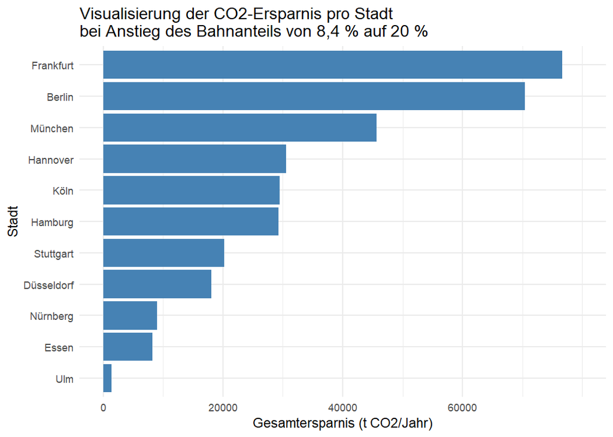

*4. CO2-Ersparnis im Kontext*

Um die Einsparungen anschaulich darzustellen, lässt sich die CO₂-Ersparnis durch einen Umstieg vom Auto auf die Bahn in Mallorca-Flügen übersetzen. Dabei entspricht ein Hin- und Rückflug nach Mallorca etwa 750 kg CO₂. Ein Umsteiger in Berlin spart pro Jahr so viel CO2 wie etwa 2,1 Flüge nach Mallorca, in Hannover knapp 2,5 Flüge und in Ulm etwa 0,2 Flüge. Insgesamt summiert sich über alle 11 Städte hinweg die CO2-Ersparnis bei einem Anstieg des Bahnanteils von 8,4% auf 20% auf rund 450.000 Mallorca-Flügen.

Diese Darstellung zeigt anschaulich, dass sowohl einzelne Pendler als auch die kollektive Umstellung auf die Bahn einen erheblichen Beitrag zur Klimaverbesserung leisten.

*Die nachfolgende Tabelle zeigt die jährliche CO₂-Gesamtersparnis pro Stadt sowie das entsprechende Äquivalent in Mallorca-Flügen.*

CO2-Ersparnis pro Stadt bei Anstieg des Bahnanteils von 8,4 % auf 20 %

| Stadt | Gesamtersparnis (t CO2/Jahr) | Ersparnis in Mallorca-Flügen |
| --- | --- | --- |
| Berlin | 70.400,34 | 93.867,12 |
| Düsseldorf | 18.074,68 | 24.099,57 |
| Essen | 8.155,04 | 10.873,39 |
| Frankfurt | 76.661,67 | 102.215,55 |
| Hamburg | 29.277,27 | 39.036,36 |
| Hannover | 30.539,09 | 40.718,79 |
| Köln | 29.468,55 | 39.291,41 |
| München | 45.662,93 | 60.883,90 |
| Nürnberg | 9.030,77 | 12.041,02 |
| Stuttgart | 20.159,62 | 26.879,50 |
| Ulm | 1.326,74 | 1.768,99 |

*5. Fazit*

Die Analyse verdeutlicht, dass der Umstieg vom Auto auf die Bahn erhebliche CO2-Einsparungen ermöglicht. Jeder einzelne Pendler kann zwischen 167 kg und 1.908 kg CO2 pro Jahr einsparen. Auf Stadtebene summieren sich diese Einsparungen zu mehreren zehntausend Tonnen CO2, wobei die Gesamtersparnis aller 11 Städte bei über 450.000 Mallorca-Flügen liegt. Die Ergebnisse zeigen, dass eine Erhöhung des Bahnanteils ein effektiver Schritt ist, um den CO2-Ausstoß im Pendlerverkehr nachhaltig zu reduzieren.

# Anhang

## Anhang A: Beschreibung der bereitgestellten Datensätze

### 1. Bahnhof-Kreis-Mapping (`bahnhof_ags_mapping.csv`)

Dieses Mapping ist essenziell für die Verknüpfung von Bahn- und Pendlerdaten. Die Bahndaten sind auf **Bahnhofsebene** (z.B. “München Hbf”), die Pendlerdaten auf **Kreisebene** (z.B. “München, Landeshauptstadt”). Der AGS (Amtlicher Gemeindeschlüssel) ist der Schlüssel, der beide Welten verbindet.

**Wichtige Variablen:**

- `station_name`: Name des Bahnhofs
- `ags`: Amtlicher Gemeindeschlüssel (5-stellig für Kreise)
- `kreis_name`: Name des Landkreises/der kreisfreien Stadt

### 2. Fahrtzeit-Vergleich OSRM (`fahrtzeit_osrm_vergleich.csv`)

Für einen fairen Vergleich Auto vs. Bahn brauchen wir **realistische Fahrtzeiten**. OSRM (Open Source Routing Machine) berechnet echte Straßenrouten basierend auf OpenStreetMap – keine Luftlinien, sondern tatsächliche Straßenverbindungen mit Abbiegevorgängen, Geschwindigkeitsbegrenzungen und Straßentypen.

**Wichtige Variablen:**

- `stadt`: Zielstadt der Pendlerstrecke
- `strecke_name`: Beschreibung der Route (z.B. “Dachau $\rightarrow$ München”)
- `auto_distanz_km`: Fahrstrecke mit dem Auto in km
- `auto_hvz_min`: Fahrzeit Auto in der Hauptverkehrszeit (mit Staufaktor)
- `bahn_planzeit_min`: Fahrzeit laut Fahrplan
- `bahn_verspaetung_min`: Durchschnittliche Verspätung
- `bahn_real_min`: Realistische Bahnfahrzeit (Fahrplan + Verspätung)

**Wie wurde das Routing durchgeführt?**

1. **Koordinaten ermitteln:** Für jede Pendlerstrecke wurden Start- und Zielkoordinaten definiert (z.B. Stadtzentrum Dachau $\rightarrow$ München Hauptbahnhof).
2. **OSRM-API abfragen:** Über die öffentliche OSRM-Demo-API (`router.project-osrm.org`) wurden für jede Route Distanz und Fahrzeit abgefragt. Die API gibt die schnellste Route zurück, basierend auf dem aktuellen Straßennetz.
3. **Staufaktor anwenden:** Die OSRM-Basisfahrzeit entspricht einer Fahrt bei freiem Verkehr. Für die Hauptverkehrszeit (HVZ) wurde ein Staufaktor von 1,3-1,5 angewendet, basierend auf den INRIX-Daten der jeweiligen Stadt.
4. **Bahn-Daten ergänzen:** Die Bahnfahrzeiten stammen aus dem DB-Fahrplan, ergänzt um die durchschnittliche Verspätung aus unserer Analyse.

**Weiterführende Links:**

- [OSRM Projekt-Website](http://project-osrm.org/) – Dokumentation und Demo
- [OSRM API-Dokumentation](http://project-osrm.org/docs/v5.24.0/api/) – Technische Details zur API
- [OpenStreetMap](https://www.openstreetmap.org/) – Die Kartendaten, auf denen OSRM basiert
- R-Paket [`osrm`](https://cran.r-project.org/package=osrm) – Für eigene OSRM-Abfragen in R

### 3. Ulm-Pendlerrouten (`ulm_pendlerrouten.csv`)

Da Sie in Ulm studieren, analysieren wir die wichtigsten Pendlerrouten in die Stadt genauer. Dieser Datensatz enthält die 5 wichtigsten Einpendler-Gemeinden mit detaillierten Informationen zur Erreichbarkeit.

**Wichtige Variablen:**

- `start_ort`: Startgemeinde der Pendlerroute
- `ziel_ort`: Zielort (Ulm)
- `auto_dauer_min`: Fahrzeit mit dem Auto
- `auto_hvz_min`: Fahrzeit Auto in der Hauptverkehrszeit
- `bahn_fahrplan_min`: Bahnfahrzeit laut Fahrplan
- `bahn_real_min`: Realistische Bahnfahrzeit
- `hat_bahnhof`: TRUE/FALSE – hat der Startort einen Bahnanschluss?
- `pendler_geschaetzt`: Geschätzte Anzahl Pendler auf dieser Route

### 4. Entgeltstatistik (`ba_entgeltstatistik_2024.csv`)

Um die volkswirtschaftlichen Kosten von Verspätungen zu berechnen, brauchen wir **regionale Lohndaten**. Diese haben wir von der Bundesagentur für Arbeit heruntergeladen.

**Wichtige Variablen:**

- `kreis_name`: Name des Kreises/der Stadt
- `ags`: Amtlicher Gemeindeschlüssel
- `medianentgelt_brutto_monat`: Median-Bruttomonatsentgelt in Euro

**Quelle:** Bundesagentur für Arbeit, Entgeltstatistik 2024

[^1]: Quelle: https://www.deutschebahn.com/de/konzern/konzernprofil/zahlen_fakten/puenktlichkeitswerte-6878476
[^2]: Quelle: https://www.deutschebahn.com/de/konzern/konzernprofil/zahlen_fakten/puenktlichkeitswerte-6878476
[^3]: Quelle: https://www.umweltbundesamt.de/system/files/medien/366/bilder/dateien/vtv_2024_pv_tab_pdf.pdf